# Agricultural Service Delivery and Smallholder Farm Performance in Ghana

Benjamin Addo, Ralph Armah, Francis Tsiboe

# Abstract

**Keywords:** Extension services; cooperatives; farm performance; technical efficiency; meta-frontier; Ghana

**JEL classification:** Q12, Q16, O13, D24

# 1. Introduction

[[OUTLINE ¶1. HOOK. Open on the thing itself, not on the literature, and use no citations. An extension officer arrives in a village with advice. Two different things can follow: the farmer is brought within reach of a way of producing that was not available before, or the farmer is helped to come closer to the best they could already have done with what they had. Establish that these are different outcomes calling for different interventions, and that a comparison of output between served and unserved communities cannot separate them. Close on the stakes: extension is a standing recurrent budget commitment across the region and is judged on exactly that comparison, so where the two effects run in opposite directions a single productivity measure can return almost nothing while both are large. That last sentence is the paper in miniature and the rest of the introduction unpacks it.]]

[[OUTLINE ¶2. WHAT THE LITERATURE HAS AND HAS NOT DONE. Two moves, in order. First, that the field already has the instrument for this distinction: fit a frontier to each group and envelop both with a meta-frontier [@Battese2004; @ODonnell2008], and note that in Ghana it has been applied repeatedly to attributes of the farmer and the farm [@Tsiboe2019; @Tsiboe2021; @Tsiboe2021b; @Tsiboe2022; @Ansah2023; @Asravor2024; @Adaku2022]. Second, the omission: service delivery has not been examined this way. Where extension appears in that work it is a covariate in the inefficiency function, not the boundary determining which technology is available. Say why that is substantive rather than cosmetic, which is that an advisory service is precisely the institution that might do either. Keep this brief. ¶9 makes the same point at length and this is only the trailer.]]

[[OUTLINE ¶3. GHANA, AND CLOSE ON THE QUESTION. Why this setting suits the distinction. Open with the institutional arrangement, then let the surveys describe the environment, then draw the inference that motivates the paper.

Three features, each carrying one or two numbers and no more. Provision is close to a public monopoly (Table 2, share/Pooled, v1 against v2 and v3; the two private channels are small enough to need one decimal). Access is contact-based rather than infrastructural (Table 3, v3 against v1 and v2). The menu is agronomically narrow (Table 4, v1 and v2 against v6, v7 and v4).

The inference to draw: a service consisting overwhelmingly of advice on how to use inputs a farmer already has is more plausibly an intervention in efficiency than in technology. That is what makes the decomposition a real question rather than a formality. Then the closing sentence states the question itself, and ¶4 breaks it into parts.

Do not re-narrate Section 3, and keep out of the crop rows. Pooled figures only.

[[CITE: the institutional sentences that open this paragraph. Ministry of Food and Agriculture delivery through district-level staff, and decentralisation to district assemblies over the survey period. This is the only claim in the section resting on literature the bibliography does not hold, and Section 3's second paragraph needs the same source. Do not build the sentence around a citation that does not exist yet.]]]]

[[OUTLINE ¶4. THE QUESTIONS. Three of them, enumerated, in the manner of resource_extraction. Whether farmers in served communities operate a different technology from comparable farmers elsewhere; whether any difference in overall performance comes from the technology available, from the efficiency with which it is used, or from both; and whether the answer depends on who provides, on what is provided, and on when it is observed. Then say what an answer looks like, which is a sign and a magnitude on each of two components rather than one number on their product, and define the three measures once, since the whole paper turns on holding them apart.]]

[[OUTLINE ¶5. DATA. Opens "To answer these questions". Three rounds of the Ghana Living Standards Survey, the operator count, the three survey years, and the community questionnaire as the source of the service measures. The important sentence is what the treatment is and is not: a property of the enumeration area, not of the household, so it is not jointly determined with a farmer's own productivity, and the price is that it records availability rather than uptake and understates the participant contrast. State that price here rather than saving it for the limitations, because ¶9 claims it as a contribution and cannot do so honestly otherwise. Then coverage by round, and one sentence naming the three institutional sources and the eight content categories that the disaggregations use.

Numbers: objs$prevalence$n_all, and objs$prevalence$share$services0 by round.]]

[[OUTLINE ¶6. METHODS, AND THE CEILING. Short, and it is scaffolding rather than argument. The meta-stochastic frontier [@Battese2004; @ODonnell2008]: a separate translog frontier for served and unserved communities, both enveloped by a common meta-frontier. Make the contrast with the alternative explicit, since it is the methodological heart of the paper: this is a different exercise from entering a service dummy as a regressor on one shared frontier. Then matching, one to one on observables before estimation, with both samples reported so the contribution of matching can be read off the table; then jackknife standard errors over enumeration areas. Close on the ceiling in one or two sentences: selection on observables, community availability rather than individual receipt, so what follows are associations, with Section 4.4 carrying the full statement. Getting this in here lets ¶7 and ¶8 report without qualifying every clause.]]

[[OUTLINE ¶7. HEADLINE RESULT, and this is the paragraph a reader will remember, so give it nothing else to do. The two margins run in opposite directions: served communities sit on a frontier further below the meta-frontier, and their farmers use that frontier better. Give both levels and both differences, note that both are significant at the 1 percent level, then the near-cancellation in the product. Close on the general point, which is the paper's most portable claim: an evaluation resting on aggregate performance alone would have recovered a figure close to zero and concluded that service delivery makes little difference, while two large effects were present and offsetting.

Do not explain why the technology component is negative. That is Section 6's work and the introduction should not pre-empt it.

Numbers: the tgr, te and mte blocks of objs$eff$services0.]]

[[OUTLINE ¶8. THE TWO DISAGGREGATIONS, presented as evidence rather than as a list. Both bear on which component behaves like a consequence of the services. By service content, the technology component barely moves across the four estimable types while the efficiency component swings across the same four; draw the conclusion, which is that what a menu contains bears on how well farmers use the frontier available and very little on which frontier that is. By survey round, the technology gap closes to an estimate not distinguishable from zero while the efficiency difference holds. Then the consequence of one moving and the other not, which is that their product changes sign across the period, so any single summary figure averages over a comparison that reverses direction inside it.

Numbers: the $provided$tgr and $provided$te fields in objs$by_service; objs$by_wave$tgr$gap, $te$gap and $mte$gap by round.]]

[[OUTLINE ¶9. CONTRIBUTIONS, WITH ANTECEDENTS FOLDED IN. The structural point of the section. Three contributions, and each one opens on what the existing literature does and closes on what this paper does instead, so that gap and answer arrive together.

One, the boundary. Ghanaian work has placed it at attributes of the farmer and the farm [@Tsiboe2019; @Tsiboe2021; @Tsiboe2021b; @Tsiboe2022; @Ansah2023; @Asravor2024; @Adaku2022] and applied meta-frontier work elsewhere at seed variety [@TweneboahKodua2022], production practice [@Birhanu2022] and resource endowment [@Uddin2014]. This paper places it at the community's institutional service environment, which is what makes the two channels separable at all.

Two, measurement. Extension exposure in this literature is typically self-reported receipt, jointly determined with the performance being explained. This paper uses the service environment of the enumeration area across three nationally representative rounds, and repeats the price named in ¶5 rather than quietly dropping it.

Three, the decomposition as the finding. Group membership is not randomly assigned and the field's answer has been matching or an explicit selection correction [@Mayen2010; @CrespoCebada2014; @Tiedemann2013; @BravoUreta2021; @Asmare2022]. This paper adopts that and then asks which of the two recovered components behaves like a consequence of the treatment, using service content and survey round as the test. That the two move in opposite directions, and that only one responds to what services contain, is the result rather than a step toward one.

Close on external relevance in one sentence: Ghana is the setting, but the measurement problem is general to any programme evaluated on aggregate farm performance.]]

[[OUTLINE ¶10. ROADMAP. Two or three sentences, customised rather than generic. Section 2 data and the service measures, Section 3 service delivery as the surveys record it, Section 4 the frontier, the matched sample and what the design identifies, Section 5 results, Section 6 interpretation, Section 7 conclusions. Supplementary exhibits in the appendix.]]

# 2. Data

## 2.1 Data sources and construction

This study uses farm-level data from the three most recent Ghana Living Standards Surveys: GLSS5, conducted in 2005/06; GLSS6, conducted in 2012/13; and GLSS7, conducted in 2016/17. The GLSS surveys are repeated cross-sectional household surveys that use a two-stage sampling design, with enumeration areas selected in the first stage and households selected in the second stage. We rely on the consolidated farmer-level GLSS dataset developed by Tsiboe (2020), which harmonizes farm production outcomes across survey rounds and has been used to study agricultural productivity across multiple Ghanaian crop value chains (F. Tsiboe and Osei, 2019; F. Tsiboe and Mensah-Bonsu, 2022; Tsiboe, 2021a, 2021b; Tsiboe et al., 2021). All monetary values are expressed in constant 2016/17 Ghana cedis using the national consumer price index.

Two conventions on weighting apply, and they differ by purpose. The descriptive statistics in Tables 1 to 5 and S3 to S4 are unweighted. Every comparison they report is made within a survey round, between groups drawn from those same rounds, so the design weight enters both sides of each contrast. Reporting the sample rather than the population also keeps the descriptive tables on the same footing as the estimation sample the frontier is fitted to. The frontier estimation is weighted. The household design weight enters the likelihood, so the technology a farmer is measured against is the technology of the population that farmer represents. Where a statistic in this paper describes the sample it is unweighted; where it describes the frontier it is weighted. The descriptive means are not national estimates and should not be read as such.

Although the consolidated dataset provides harmonized farm-level outcomes, it does not directly contain the community-level agricultural service provision indicators required for this study. To construct these measures, we returned to the agriculture section of the GLSS community questionnaire, which records the service environment of the enumeration area rather than of any individual household, and merged it into the farmer-level data using survey and enumeration-area identifiers. The community questionnaire is administered not to households but to a panel of community opinion leaders, and the survey protocol requires that panel to reflect the occupational, ethnic, gender, and religious composition of the community. Our treatment measures are key-informant reports of what is *available* in a locality. They are not administrative records, and they are not household reports of services *received*. That distinction governs how the estimates should be read, and we return to it below.

Variables are harmonized using GLSS7 as the reference structure, since it is the most recent round and organizes the service questions most clearly. GLSS6 is numbered identically across the relevant block; GLSS5 requires renaming, because it lacks the compliance item and its association, cooperative, and tractor questions therefore sit one position earlier. Where a community contributes more than one record, indicators are collapsed to one observation per survey and enumeration area by taking the maximum, so a service counts as available if any informant record reports it. Appendix Table S1 gives the source question and construction rule for every variable and Table S2 documents the cross-round mapping; Note S1 sets out the harmonization, the collapse rule and their consequences in full. One item is not available in GLSS5 at all: compliance with extension guidance. Every statistic involving it is restricted to GLSS6 and GLSS7, so Table 5 rests on a smaller denominator than Tables 2 to 4, and its note records this.

For the meta-stochastic frontier analysis we define four indicators of the institutional source of service delivery. A community is classified as having: (i) *any service source* if it has an agricultural or fishing association, an agricultural cooperative, or active extension; (ii) an *association* source if an agricultural or fishing association is present; (iii) a *cooperative* source if farmers participate in an agricultural cooperative; and (iv) an *active extension* source if an extension officer visits farmers in the community. These are four separate binary treatments, each estimated against its own pair of group-specific frontiers, rather than four levels of a single categorical treatment. A second set of indicators captures the *content* of services available: planting or seed-use support, mechanization, credit, irrigation, animal husbandry, fertilizer and other agrochemical inputs, post-harvest, marketing or storage support, communal labour, employment, and record-keeping. These enter the analysis as a disaggregation of the estimated gap rather than as treatments.

Under these definitions, 65.5% of farmers in GLSS5 lived in a community with at least one agricultural service source, 61.9% in GLSS6 and 62.8% in GLSS7. That is a stable majority rather than a trend. The composition beneath it is not stable. Active extension reaches 52.7%, 49.5% and 56.4% of farmers across the three rounds; association presence falls from 27.9% to 24.7%; and cooperative participation moves non-monotonically, from 10.9% to 21.4% and back to 13.2%. A constant headline share is consistent with substantial churn in how service is delivered. That is the paper’s reason for treating the four sources separately rather than as one aggregate.

Unless otherwise stated, terms such as *“association community”* or *“community with active extension”* in this paper refer to this community-level classification. Every sampled farmer residing in a classified enumeration area is treated as exposed, regardless of whether that farmer personally received a service, belonged to the association, or met an extension officer. This is the paper’s central interpretive commitment: the estimates describe the effect of operating in a service-provisioned locality, not of individual programme participation, and they will understate the difference between participants and non-participants to the extent that provision and uptake diverge.

Three features of the instrument bound what these measures can support. Service provision is reported by community informants, so the treatment records availability rather than receipt, and a community counted as served may contain farmers who never used the service. The service-content items are asked only where a provider exists, so their absence for unserved communities is assigned by construction rather than measured, and content contrasts compare a measured category against a definitional one. That is the only design the questionnaire’s skip pattern permits. And implausible values are set to missing before the community-level collapse: extension distances of 999 kilometres or more, and tractor counts of 99 or more, are treated as non-responses rather than as observations. Both rules are applied to the community record rather than to the farm, so a single suppressed community removes the variable for every farm in its enumeration area.

Neither suppression rule bites hard, removing 37 records between them out of the 1,960 behind GLSS5 to GLSS7. Ordinary item non-response on the same two questions is a larger matter by an order of magnitude, and Note S1 reports both sets of counts. Distance to the nearest extension office is unobserved for close to a quarter of communities, which is why it enters this study as a descriptive covariate and never as a treatment or a frontier input.

The analysis is restricted to crop farmers with reported yields, measured in kilograms per hectare, between the 2.5th and 97.5th percentiles within each survey round and crop. The final sample includes 22,519 farm operators: 6,124 in GLSS5, 10,431 in GLSS6 and 5,964 in GLSS7. Each cultivates at least one of the following crops: banana, beans, cashew, cassava, citrus fruits, cocoa, coconut, cocoyam, cotton, kenaf, maize, millet, oil palm, peanuts, plantain, potato, rice, sorghum, yam, sugarcane, tomato, pepper, okra, onion, eggplant, and other reported crops.

## 2.2 Descriptive statistics

Table 1 summarises crop producers in Ghana, pooled and disaggregated by whether any agricultural service source is available in the farmer’s community; Tables S3 and S4 repeat the exercise for each of the three service sources separately, in levels and in trends. Of the 22,519 farm operators in the analysis sample, 14,215 are in served communities and 8,304 are not. Throughout these tables a dagger marks a service-status term that is significant at the ten percent level in the trend model behind the row, not a test of the raw difference in means; on a sample of this size a difference can be large and carry no dagger, or small and carry one, and we describe magnitudes rather than lean on the marker.

The two groups are close on who farms and further apart on what they produce with. Women are 24% of operators in unserved communities and 25% in served ones, a difference of no practical consequence. Operators in served communities are about a year older (47.2 years against 46.3) and have roughly nine months more schooling (4.47 years against 3.68), the largest proportional gap among the farmer characteristics. Households are marginally smaller in served communities (5.41 adult equivalents against 5.62) and dependency ratios are indistinguishable at about 1.43. None of this suggests that service provision follows the demographic composition of a community; it suggests, if anything, that it follows something the demographic composition does not capture.

Production and input use tell a different story. Output per hectare across all crops averages GH₵1,149 in served communities against GH₵1,051 in unserved ones, a gap of about nine percent. The same ordering holds for most individual crops, maize (2,390 against 2,107 kg/ha), millet (1,052 against 792), cassava, cocoyam and plantain among them. Yam runs the other way and by a wide margin (1,675 kg/ha unserved against 1,163 served), as do pepper and tomato. Farms in served communities are slightly smaller (1.82 hectares against 1.92) and use somewhat more planting material per hectare. What is most striking is how little of the input differential is technological. Only 1% of farmers report irrigation, 5% mechanized services and 15% credit, and the served-unserved differences in all three are one percentage point or less. These are the technologies a technology gap could plausibly reflect, and at these levels of access there is very little of them in either group to differ over.

Disaggregating by source, in Tables S3 and S4, shows that the sources are not interchangeable. Farmers in extension communities (n = 11,752) and association communities (n = 5,713) both out-produce the pooled average for most crops, but they are distinguished in different ways. The association group stands out on schooling, at 5.22 years against 4.17 pooled, the largest educational gap anywhere in the descriptive tables. The extension group stands out on scale and mechanization. The cooperative group (n = 3,690) is the smallest and the most erratic across crops: its cocoyam and okra cells sit far above the pooled means and its rice and beans cells far below, on cell counts that do not support a reading either way. We note the pattern and decline to interpret it, which is the same restraint the sibling literature has had to exercise where crop cells thin out.

The trends in Table S4 matter more than the levels for what follows, because they run in the direction that makes a cross-sectional comparison hardest to read. Output per hectare grew across the period in both groups but faster where services were present (10.09 percent a year against 6.36 percent), and schooling did the same (2.69 percent against 0.36 percent). Credit access fell for everyone, and fastest in unserved communities (-9.57 percent a year against -6.33 percent). Irrigation grew at 8.96 percent a year pooled, from a base low enough that the growth changes nothing about access. Read together, the levels and the trends describe groups that are diverging on the endowments most associated with performance, not converging.

Two things follow, and they set up the rest of the paper. First, served and unserved communities differ systematically on characteristics that independently predict farm performance, so the raw differences in this section cannot be read as the contribution of agricultural services; they require a comparison between farmers who are alike on what we observe, which is what the matched design in Section 4 constructs. Second, the differences are not uniform across the four sources. Association communities differ from unserved ones in one way and extension communities in another, so a single average difference would conceal the structure it is meant to describe. That is the case for a meta-frontier, which separates the technology a group can reach from the efficiency with which it is used, and estimates both separately by source. Section 3 first sets out what agricultural service delivery in Ghana actually consists of, and Section 4 then specifies the estimator.

# 3. Agricultural service delivery in Ghana

[[OUTLINE ¶1. the regional frame, cast broadly before narrowing. Agricultural extension and farmer-organisation coverage in sub-Saharan Africa: what share of smallholders reach any advisory service, how delivery has shifted between public agencies, non-governmental providers and producer organisations over the past two decades, and what the recurring constraint has been. External literature only, no numbers from this study. Keep it to about two-thirds the length of ¶2, since the paper is about Ghana.]]

[[OUTLINE ¶2. Ghana. Ministry of Food and Agriculture extension officer-to-farmer ratios, the decentralisation of extension delivery to district assemblies and what it did to coverage, and the penetration of farmer-based organisations and cooperatives. This paragraph carries the institutional facts the rest of the section quantifies, so it should end where ¶3 begins, on the question of who actually provides the service a farmer encounters. External literature only.]]

[[OUTLINE ¶4. Table 3, what form access takes. Extension in Ghana is contact rather than infrastructure. Communities where an officer visits and nothing else is present are the single largest served state, about a third of farmers, while communities with an office but no visit, or a stationed officer but no visit, are each rarer than one farmer in forty. Lookups: tbl_pct("table3", "share/Pooled", "v3") for visits only, "v1" and "v2" for the two passive states, "v6" for the fully equipped state. Section 2.1 already uses the same three figures to justify the active-extension threshold, so this paragraph should extend rather than repeat: the composition is shifting, with office-based delivery growing quickly and stationed-officer arrangements declining. Lookups: tbl_val("table3", "trend/Pooled", "v5") and "v4".

NOTE FOR WHOEVER WRITES THIS. The share of farmers in communities with no extension presence of any kind is roughly two in five, and it is NOT in Table 3, which omits it as the reference category. It is also not the complement of active extension, which Section 2.1 reports and which is a different quantity. If the paragraph wants it, add it to the exhibit or to the article objects first rather than deriving it in the text.]]

[[OUTLINE ¶5. Table 4, what the services contain. This is the most substantive paragraph in the section and it carries observation (iii). The menu is bimodal. Planting and seed-use advice and agrochemical advice each reach about half of all farmer-communities; every other service type reaches under a fifth, and irrigation advice under one percent. Lookups: tbl_pct("table4", "share/Pooled", "v1") and "v2" for the two common ones, then "v5" post-harvest, "v6" credit, "v7" mechanization, "v3" communal labour, "v8" records, "v4" irrigation. The point to draw is that Ghanaian agricultural extension is overwhelmingly agronomic advice, and that the services which would relieve capital, labour and water constraints are the ones farmers are least likely to encounter.]]

[[OUTLINE ¶6. Table 4 again, the direction of travel, carrying observation (iv). The menu is not static and it is narrowing. Agrochemical advice and mechanization support are growing; communal labour, credit, employment and animal husbandry services are all contracting, several of them fast. Lookups: tbl_val("table4", "trend/Pooled", "v7") for mechanization, "v6" credit, "v3" communal labour, "v2" agrochemicals. State the pattern rather than each number: the services being withdrawn are those that relieve capital and labour constraints, and those expanding supply advice and equipment. Whether this is a shift in provision or in what informants report is not something these data settle, and the paragraph should say so rather than assume the former.]]

[[OUTLINE ¶7. Table 5, compliance, and the close. Where advice is given, compliance is the norm rather than the exception: full compliance is the largest single category and outright non-compliance the smallest. Lookups: tbl_pct("table5", "share/Pooled", "v3") for full, "v2" partial, "v1" did not comply.

TWO CAUTIONS THAT MUST APPEAR. First, this table rests on GLSS6 and GLSS7 only, because the compliance item does not exist in GLSS5, and Section 2.1 records why. Second, its trend column is a percentage change per year computed across two survey rounds, which is an interpolation between two points rather than a trend, and the largest value in that column is implausible on its face. Report the levels and leave the trend column alone, or report it with that qualification stated.

Close the section on the service environment as a whole rather than on compliance: public, contact-based, agronomically narrow, and narrowing. That is the setting the rest of the paper measures against.]]

# 4. Methods

## 4.1 Conceptual framework

Numerous studies have established that the performance of Ghanaian farmers is influenced by various factors, including geographical location (F. Tsiboe and Osei, 2019; F. Tsiboe and Mensah-Bonsu, 2022; Tsiboe, 2021b), farmer’s age (J. Asravor and Zeller, 2024), and gender (A. A. Adaku and Clottey, 2022), among others. In the context of this study, we conceptualize agricultural service delivery as a community-level institutional environment that may shape smallholder farm performance through two related channels: technical efficiency and access to superior production technologies. Technical efficiency reflects how well farmers convert available inputs into output relative to the production frontier available to their group, while the technology gap ratio captures how close that group-specific frontier is to the best feasible production frontier available to all farmers in the sample. The decomposition is the meta-frontier framework’s (C. J. O’Donnell and Battese, 2008; G. E. Battese and O’Donnell, 2004).

Separating the two channels is the point of the exercise, because they carry different policy content. A community whose farmers are technically efficient but whose frontier lies well below the meta-frontier has an access problem: the practices are being used well, but they are not the best practices available. A community whose frontier is close to the meta-frontier but whose farmers sit well inside it has a utilisation problem instead. A single measure of productivity cannot distinguish these, and the two call for different responses. The empirical question of this paper is which of the two, if either, moves with the presence of agricultural service delivery.

The main empirical specification uses access to any agricultural service source to classify farmers into two technology groups: farmers in communities with at least one agricultural service source, and farmers in communities without any identified source. This grouping reflects the idea that communities with agricultural services may operate under a different production environment from communities without such services. Services can raise within-group technical efficiency by helping farmers use land, labor, seed, fertilizer, pesticides, and other inputs more effectively. They can also narrow technology gaps, by improving access to better practices, input information, mechanization support, credit, irrigation knowledge, post-harvest support, and market-related services. Farmers exposed to agricultural services may then be closer both to their own group frontier and to the meta-frontier. The Ghanaian evidence supports both readings without settling between them: studies of cereal, vegetable, legume and starchy-staple systems report technical inefficiency responding to extension exposure and to the managerial and demographic characteristics that mediate it (F. Tsiboe and Osei, 2019; F. Tsiboe and Mensah-Bonsu, 2022; I. G. K. Ansah and Tsiboe, 2023; J. Asravor and Zeller, 2024), while the technology-gap literature finds accessible technology sets differing systematically across groups defined by exactly this kind of institutional access (A. A. Adaku and Clottey, 2022; Tsiboe, 2021b).

Agricultural service delivery is not a single-channel intervention. Services reach farmers through agricultural or fishing associations, through agricultural cooperatives, or through active extension delivery, and the three work differently. Associations support coordination, information exchange, input access, communal labor, and marketing. Cooperatives bear on bargaining power, on access to services, and on collective action. Extension delivers technical advice and farmer-facing guidance directly. The applied meta-frontier literature has treated each of these as a technology-defining boundary in its own right: seed-variety access in Ghanaian maize (T. Tweneboah Kodua and Mensah-Bonsu, 2022), production practice in Ethiopian cereals (F. Z. Birhanu and Bimerew, 2022), and resource endowment in Bangladeshi dairy (M. M. Uddin and Peters, 2014). This paper adopts the same design for service source. For this reason, in addition to the main specification based on access to any agricultural service source, the study conducts separate analyses using service-source measures to assess whether farm performance differs by the channel through which agricultural support is delivered. Section 2.1 sets out why these three contrasts share a comparison group and are therefore not independent of one another.

The study also considers the content of services available to farmers. Agricultural support may focus on planting or seed use, mechanization or agricultural equipment, credit, irrigation, animal husbandry, fertilizer or agrochemical input use, and post-harvest, marketing, or storage services. The pathways differ. Planting and seed-use advice bears on crop establishment; mechanization relaxes labor and timeliness constraints; credit eases liquidity constraints; irrigation reduces exposure to rainfall variability; husbandry support matters in mixed farming systems; input advice bears on fertilizer and pesticide decisions; and post-harvest or marketing support reduces losses and eases market participation. Content enters the analysis as a disaggregation of the estimated gap rather than as a separate treatment, and Figure 3 reports it that way.

## 4.2 Meta-stochastic frontier analysis

This study examines whether agricultural service delivery is associated with differences in smallholder farm performance in Ghana. The analysis focuses on three related outcomes: technical efficiency, technology gap ratios, and meta-technical efficiency. To estimate these outcomes, we apply the meta-stochastic frontier framework (C. J. O’Donnell and Battese, 2008; G. E. Battese and O’Donnell, 2004), which allows farmers operating under different service environments to have separate group-specific production frontiers while also being compared to a common meta-frontier. This framework is appropriate because farmers in communities with agricultural service access may face a different production environment from farmers in communities without such access.

In the main specification, farmers are separated into two groups based on whether their community has access to any agricultural service source. The first group consists of farmers in communities with at least one agricultural service source, including agricultural or fishing associations, agricultural cooperatives, or active extension delivery. The second group consists of farmers in communities without any identified agricultural service source. Separate stochastic frontier production functions are estimated for these two groups. The group-specific frontiers provide estimates of technical efficiency, which measure how efficiently each farmer converts input into output relative to other farmers operating in the same service environment.

The group-specific stochastic frontier for farmer $i$, service group $j$, and survey round $t$ is specified as a translog production function:

$f^{j}\left( x_{ijt} \right) = \ln y_{ijt} = \beta_{0j} + \sum_{k}^{}{\beta_{kj}\ln x_{kijt}} + \frac{1}{2}\sum_{s}^{}{\sum_{k}^{}{\beta_{skj}\ln x_{kijt}\ln x_{sijt}}} + \mathbf{\beta}_{h}\mathbf{h}_{ijt} + v_{ijt} - u_{ijt}$

$u_{ijt}\sim N^{+}\left\lbrack 0,\exp\left( \mathbf{w}_{ijt}\mathbf{\alpha} \right) \right\rbrack$, $v_{ijt}\sim N\left( 0,\sigma_{vj}^{2} \right)$ (1)

where $y_{ijt}$ is crop output for farmer $i$ in service group $j$ and survey round $t$. The vector $x_{kijt}$ contains six production inputs: land, planting materials, family labor, hired labor, fertilizer, and pesticide, in that order. The vector $h_{ijt}$ holds the intercept shifters: the shares of cultivated area under each listed crop, the survey round, and the agroecological zone. These allow the level of the frontier to differ across cropping systems, periods and ecologies without allowing its slope to. The term $v_{ijt}$ captures random shocks outside the farmer’s control, while $u_{ijt}$ captures technical inefficiency. The inefficiency term is modelled as a function of farmer and farm characteristics $w_{ijt}$: the logarithms of age and years of schooling, crop diversification, and indicators for survey round, gender, agroecological zone, credit access, land ownership and mechanization. Table S7 reports the full frontier and Table S8 the inefficiency function.

Three specification choices deserve a word. We adopt the translog rather than the Cobb-Douglas form for its flexibility. A likelihood-ratio test rejects the Cobb-Douglas restriction decisively on the pooled national frontier (LR = 1,208.7 on 21 degrees of freedom, p < 0.001), and on each group frontier separately; the Cobb-Douglas estimates are reported alongside the other alternatives in Figure S2 so the cost of the choice can be read off directly. We assume a half-normal distribution for the inefficiency term, having found more flexible distributions unstable in the subgroup fits; exponential, generalised-exponential and Rayleigh alternatives are estimated and reported in Figure S2. And the household design weight enters the likelihood, so the frontier describes the population each farmer represents rather than the achieved sample.

Preliminary translog estimates violated the theoretical properties a production function is required to satisfy, as unrestricted translog fits routinely do. We therefore impose monotonicity during estimation and evaluate quasi-concavity afterwards. After correction, monotonicity is satisfied for 40.53 percent to 99.98 percent of observations and curvature for 17.32 percent to 37.06 percent, depending on the frontier (Table 6). The spread is wide and we do not present it as satisfactory: the meta-frontier satisfies monotonicity almost everywhere, while the served-group frontier satisfies it on well under half its observations, and curvature holds on a minority of observations under every frontier. Estimates that rest on the curvature-violating region should be read with that in mind. The share of total variance attributable to inefficiency rather than noise ranges from 0.583 to 0.980 across the frontiers, so the inefficiency component is substantial in every specification and the frontier framework is doing real work rather than fitting noise.

Technical efficiency for each farmer is calculated as:

${TE}_{ijt} = \ E\left\lbrack \exp\left( - u_{ijt} \right)|{\widehat{\varepsilon}}_{ijt} \right\rbrack$ (2)

where $TE_{ijt}$ measures the farmer’s efficiency relative to the service-group-specific frontier. In this framework the service indicator does not enter as a conventional regression covariate; it defines the group-specific production technology. That is what allows the analysis to ask whether farmers in served communities operate on a different frontier, rather than only whether they sit at a different point on a common one.

In the second step, the estimated group-specific frontiers are enveloped by a common meta-frontier, representing the best feasible production technology available across all farmers in the sample regardless of service environment:

$f^{M}\left( x_{ijt} \right) = \ln{\widehat{y}}_{ijt} = \beta_{0M} + \sum_{k}^{}{\beta_{kM}\ln x_{kiMt}} + \frac{1}{2}\sum_{s}^{}{\sum_{k}^{}{\beta_{skM}\ln x_{kiMt}\ln x_{siMt}}} + \mathbf{\beta}_{h}\mathbf{h}_{ijt} - u_{Mijt}$ (3)

where $u_{Mijt} \geq 0$ captures the distance between the group-specific frontier and the meta-frontier. The technology gap ratio is then defined as:

${TGR}_{ijt} = \frac{f^{j}\left( x_{ijt} \right)}{f^{M}\left( x_{ijt} \right)} = e^{- u_{iM}} \leq 1$ (4)

The technology gap ratio measures how close the production technology available to a farmer’s service group is to the best feasible technology represented by the meta-frontier. A value closer to one indicates a smaller technology gap, while a lower value indicates that the group-specific frontier lies further below the meta-frontier.

Meta-technical efficiency combines within-group technical efficiency and the technology gap ratio:

${MTE}_{ijt} = \ f^{j}\left( x_{ijt} \right)\left\lbrack f^{M}\left( x_{ijt} \right)e^{v_{ijt}} \right\rbrack^{- 1} = {TGR}_{ijt} \times {TE}_{ijt}$ (5)

This measure captures each farmer’s performance relative to the overall meta-frontier. It reflects both how efficiently the farmer uses available inputs within the service environment and how close that service environment is to the best available production technology. Because MTE is the product of the two, a service source can raise MTE by raising either component, and the three measures must be read together: an improvement in TE offset by a deterioration in TGR leaves MTE unmoved while describing a substantively different situation.

Input elasticities are computed from the first-order partial derivatives of the fitted frontier, evaluated at each observation and averaged with sampling weights; returns to scale are their sum. Reporting them serves a second purpose beyond describing the technology. If service provision operated only by shifting the level of output, the elasticities would be common across groups and only the intercepts would differ; group-specific elasticities are what make the two frontiers genuinely two technologies rather than one technology at two heights. Table 6 reports them for both groups and for the meta-frontier.

Given the differences in sampling, question structure, and implementation across the GLSS rounds, treating the pooled data as a single cross-section would risk masking real variation. Equations (1) to (5) are estimated within survey round, and the efficiency scores and elasticities are averaged across rounds afterwards. Each comparison is thus made between farmers surveyed under the same instrument in the same year, and the pooled figures reported throughout are averages of within-round comparisons rather than comparisons across pooled data.

After estimating the main model, farmer-level technical efficiency, technology gap ratios, and meta-technical efficiency are predicted and summarised across age, gender, education, crop and region, and across the content of services available. This is the basis of Figures 3 to 5. It is descriptive disaggregation of an estimated gap rather than a separate identification strategy, and it is reported as such.

## 4.3 Balanced sample construction

Agricultural services are not randomly distributed across communities. Communities with service access may differ from those without in location, infrastructure, crop mix, commercialization, farmer organization, land ownership, education, and broader institutional capacity, and Section 2.2 shows several of these differences directly. Comparing group-specific frontiers estimated on such samples would confound the technology available to a group with the composition of the group itself. Our empirical strategy rests on a balanced matched sample. The purpose of matching here is not to establish causal effects but to construct a more comparable analytic sample for the meta-stochastic frontier, so that the two frontiers describe farmers who are alike on what we observe. This follows applications of meta-frontier methods in productivity studies where group assignment is associated with observed characteristics (Asmare et al., 2022; Bravo-Ureta et al., 2021; Crespo-Cebada et al., 2014; Mayen et al., 2010; Tiedemann and Latacz-Lohmann, 2013).

The grouping variable for matching is access to any agricultural service source. This broad measure is used because the service-source and service-content indicators are nested within it, so a single matched sample supports every contrast the paper reports. Farmers are matched on demographic characteristics, namely age, education, marital status, religion, ethnicity, and relationship to the household head; on household size, dependency ratio and female share; and on crop diversification and the share of cultivated area under each listed crop, together with land ownership and credit access. Matching is conducted strictly within strata defined by operator gender, survey round, region, agroecological zone, and rural or urban locality, so that no match crosses a boundary along which the production environment or the instrument itself changes.

Balancing treated and untreated groups across this many continuous and categorical covariates admits no single obvious metric, so we do not choose one a priori. We implement one-to-one nearest-neighbour matching under eight distance specifications: Euclidean and scaled Euclidean distance, Mahalanobis (Rubin, 1980) and robust Mahalanobis distance (Rosenbaum, 2020), and propensity scores under logit, probit, complementary log-log and Cauchit links. Each is evaluated on standardized mean differences, variance ratios, and Kolmogorov–Smirnov statistics, with optimal balance indicated by standardized differences close to zero and variance ratios close to one (Rubin, 2001; Stuart, 2010). Table S6 reports all three diagnostics for every specification together with the composite criterion that ranks them, and Figure S1 reports every specification against every covariate.

Scaled Euclidean distance is used in the main analysis. Two features of that choice should be visible rather than asserted. The distance-based metrics separate from the propensity-score metrics decisively, every propensity-score link being worse on all three diagnostics. They barely separate from each other. Scaled Euclidean and Mahalanobis are indistinguishable on standardized mean differences and differ in the fourth decimal of the composite criterion, so the ranking between the top two is not a finding and nothing in the paper turns on it. Figure S2 reports the estimates under alternative matching metrics. The matched sample retains 14,616 of the 22,519 farm observations. Because matching discards unmatched treated units as well as unmatched controls, the matched sample is not a random subsample of the analysis sample, and results on it describe the region of covariate overlap rather than the full population of Ghanaian crop farmers.

Every estimate in the paper is reported on both samples. Table 6 and Figure 1 carry the matched and unmatched frontiers side by side, so the contribution of matching to each gap can be read off the exhibit rather than taken on trust.

To estimate standard errors we use a jackknife resampling procedure. The correction that imposes monotonicity in Equations (1) and (3) prevents estimation of a conventional variance-covariance matrix, so an analytic standard error is not available. For each survey round we construct 100 resampled datasets, each excluding one enumeration area, and re-run the entire procedure on every one of them: the group-specific frontiers, the matching, and the meta-frontier. The dispersion of the estimates across resamples gives the reported standard errors. This propagates the uncertainty introduced by the matched-sample construction as well as by estimation, which an analytic standard error conditional on the matched sample would not, and it respects the clustering of the survey design by resampling at the level at which the sample was drawn.

## 4.4 What the design identifies

Several limitations bound the interpretation of what follows, and we state them here rather than after the results.

Identification rests on selection on observables. Matching balances the farmer, household and production characteristics listed above within strata defined by gender, round, region, agroecological zone and locality, together with overlap on those characteristics. It cannot address confounding from unobserved determinants of both service provision and farm performance: soil quality, distance to markets and roads, road and electricity infrastructure, household wealth, the strength of local institutions, or the political salience of a community to the agencies that allocate extension staff. The last of these is the sharpest case, because service placement is a decision made by an agency with objectives of its own. If extension is directed toward communities with higher agricultural potential, then service provision and productive capacity are jointly determined by something we do not observe, and the estimated gap will absorb it. Stronger correction would require a valid exclusion restriction, and the GLSS contains no instrument for community service provision that is credibly unrelated to farm performance. We interpret the estimated differences in TGR, TE, and MTE as associations conditional on observables in a balanced sample, not as causal effects of agricultural service delivery. Where the discussion below uses the language of influence or effect, it should be read in that sense.

The treatment is measured at the community level and describes availability, not receipt. A farmer in a served community who never met an extension officer is counted as exposed, and a farmer who sought advice privately in an unserved community is counted as unexposed. This attenuates the estimated gap toward zero relative to the difference between actual participants and non-participants. The size of the attenuation depends on uptake, which the community module does not measure. We know the direction of the bias and not its magnitude.

The stable-unit-treatment-value assumption is not innocuous here and we do not assume it silently. Extension officers, cooperatives and associations operate across community boundaries, farmers in unserved communities may obtain advice from neighbours in served ones, and traders and input dealers move information the same way. Spillover of this kind contaminates the comparison group in the direction of understating the gap. Matching within region and agroecological zone makes matched pairs geographically closer, which if anything increases the risk. We cannot bound this with the data available.

Three further limitations follow from the data. The service measures are harmonized across rounds, so detail available in one round but not another is discarded to preserve comparability, and compliance with advisory guidance is observed in GLSS6 and GLSS7 only. The treatment records the presence of a service source and nothing about its intensity, quality, or duration. A community served for twenty years and one served since last season are coded alike. So are a well-staffed extension office and a nominal one. And the data are repeated cross-sections rather than a panel, so the wave-to-wave patterns describe changing associations across successive samples of farmers, not changes within farmers over time, and they cannot identify the lagged responses through which service provision is theorised to operate.

# 5. Results

This section reports what the estimation produced, in the order the exhibits present it. Table 6 carries the specification diagnostics and the input elasticities. Figure 1 disaggregates the service comparison by the four sources of provision. Figure 2 follows the comparison across survey rounds, Figure 3 across the content of the services provided, and Figures 4 and 5 across farmer characteristics, crops and regions. Tables S7 and S8 hold the full frontier and the inefficiency function; Table S5, Table S6 and Figure S1 hold the balance evidence behind the matched sample.

One convention governs every number below. A difference is reported as the served group minus the unserved group, so a positive value means farms in communities with an agricultural service source do better on that measure. The three measures are not interchangeable. The technology gap ratio describes the frontier a group can reach, technical efficiency describes how close a farmer gets to that frontier, and meta-technical efficiency is their product. A group can be worse on the first and better on the second, and the sign of the third then depends on which effect is larger.

## 5.1 Diagnostic tests

Two specification choices are settled by test rather than assumption. A likelihood-ratio test rejects the Cobb-Douglas restriction against the translog on the naive national frontier (LR = 1,208.7, 21 degrees of freedom) and on each group frontier separately (LR = 496.8 for the unserved group, 735.6 for the served group), all three below the 0.001 level. A second likelihood-ratio test, of a single common frontier against the two group-specific frontiers, returns 37,238 on the matched sample and 53,180 on the unmatched sample. Served and unserved communities do not share a technology, which is the condition the meta-frontier framework requires.

The theoretical properties are the weaker part of the specification and we report them plainly. After imposing monotonicity and evaluating quasi-concavity, monotonicity holds for 61.95 percent of observations under the unserved frontier, 65.35 percent under the naive national frontier, and 99.98 percent under the matched meta-frontier. Under the served frontier it holds for 40.53 percent, the lowest rate in the set. Curvature is satisfied less often everywhere, at 35.27 percent, 17.78 percent and 17.32 percent for the three single-technology frontiers and 37.06 percent for the matched meta-frontier. The served-group frontier is thus the least well behaved of the four, and every estimate reported below that involves it inherits that weakness.

Three tests of one-sided error support the frontier structure. On the naive national frontier the residual skewness statistic is -0.250, the third-moment statistic -15.290, and the likelihood ratio for the presence of inefficiency 2,403.788. Each rejects its null, and each rejects again on both group frontiers. The share of output variance attributable to inefficiency rather than noise is 0.635 for the unserved group and 0.583 for the served group, rising to 0.980 on the matched meta-frontier.

## 5.2 Output elasticities

The two frontiers do not weight their inputs identically, and the differences are small but systematic. The served group draws more from land, by 0.006, and more from hired labour, fertilizer and pesticide, by 0.005, 0.004 and 0.003. The unserved group draws more from planting material and family labour, where the differences run the other way at -0.008 and -0.007. All six are stored matched-sample differences and all six are significant at the 1 percent level. The difference in returns to scale, 0.002, is the only estimate in the entire elasticity block that is not statistically distinguishable from zero. Whatever separates these two technologies, it is not scale.

## 5.3 Technology adoption and technical efficiency

The aggregate comparison runs in two directions at once. Farms in served communities sit on a frontier substantially further below the meta-frontier than farms in unserved communities: the technology gap ratio is 0.940 without services and 0.852 with them, a difference of -0.088. On the same matched sample they use that frontier better, with technical efficiency of 0.606 against 0.561, a difference of 0.045. Both are significant at the 1 percent level. Both are large beside anything reported in Section 2, where no unadjusted difference between the two groups approached this magnitude.

Net of each other, almost nothing remains. Meta-technical efficiency is 0.525 for the unserved group and 0.531 for the served group. That difference, 0.006 or 1.09 percent, is significant at the 1 percent level and roughly an order of magnitude smaller than either of the two differences producing it. The overall measure is therefore the least informative of the three here, not the most: it is small because two large effects nearly cancel, and it is the same size as it would be if neither effect existed.

Agricultural and fishing associations show the same two directions at close to three times the magnitude. The technology gap difference is -0.263 against the aggregate’s -0.088, and the efficiency difference 0.113 against 0.045. At that scale the offset no longer holds, and the net difference is negative at -0.040. Cooperatives are the opposite case. Neither the technology gap difference of 0.010 nor the efficiency difference of -0.006 is statistically distinguishable from zero, yet their product is, at 0.010 and significant at the 1 percent level. Three sources, three routes, and net results that differ in sign.

Figure 2 follows the comparison round by round, and the technology gap closes across the period. The difference is -0.150 in 2005/06, -0.069 in 2012/13 and -0.007 in 2016/17. The first two are significant at the 1 percent level; the last is the only estimate in the entire series that is not distinguishable from zero. By the most recent round the frontier available to served communities is statistically indistinguishable from the frontier available to unserved ones. The efficiency difference shows no comparable movement, staying positive and significant in every round at 0.028, 0.064 and 0.039.

Because one component moves and the other does not, their product changes sign. Overall performance in served communities sits 0.040 below unserved communities in 2005/06, 0.033 above them in 2012/13, and 0.038 above them in 2016/17, each estimate significant at the 1 percent level. The pooled difference of 0.006 reported above is an average taken across a comparison that reverses direction inside the period, and no single round in the data produces it.

## 5.4 Robustness of main findings

The estimates above are properties of the matched sample, and Table 6 reports both samples so that the contribution of matching can be read directly. Without matching the technology gap difference is -0.064 against -0.088, and the efficiency difference 0.020 against 0.045; both components are understated. The net measure moves further than either. Meta-technical efficiency differs by -0.009 unmatched and 0.006 matched, which is a change of sign rather than of magnitude. Section 2.2 showed that the two groups differ on characteristics that independently predict performance, and this is what those differences are worth once removed.

Specification checks appear in Figure S2, which re-estimates the aggregate comparison under alternative functional forms, alternative inefficiency distributions and alternative matching metrics. Section 4.3 has already noted that the two best-balanced distance metrics differ only in the fourth decimal of the selection criterion, so the choice between them is not a source of variation. The naive national frontier gives one further reference point: it puts technical efficiency at 0.586 on the matched sample, between the two group-specific values, which is what a single pooled technology should produce when it averages over two.

## 5.5 Observed heterogeneity

Figure 3 disaggregates the comparison by the content of the services a community provides. Four of the eight service types support an estimate on the served side, and among those four the net differences span more than half a point: post-harvest and marketing support at 0.356, planting and seed-use advice at 0.050, agrochemical support at 0.025, and mechanization at -0.308. Section 2.1 explains why the other four service types cannot be estimated on the served side.

Decomposed, that spread sits almost entirely in one component. The technology gap difference is negative for all four and varies little across them, from -0.092 for post-harvest support to -0.049 for mechanization. The efficiency difference varies enormously, from 0.414 for post-harvest support to -0.312 for mechanization, with planting advice at 0.078 and agrochemical support at 0.051 in between. What a community’s service menu contains bears on how well farmers use the frontier available to them, and very little on which frontier that is.

One feature of the regional disaggregation is a property of the sample rather than a result, and we flag it here rather than leave it to be read as a finding. In Northern, Upper East and Upper West, and correspondingly in the Guinea and Sudan Savanah zones, the efficiency difference is estimated at exactly zero and the technology gap difference at under one percentage point in absolute value. Those are the strata in which service provision is close to universal, so the within-stratum comparison has very few unserved farms to draw on. The estimates for the three northern regions and the two savanah zones should be read as uninformative rather than as evidence that agricultural services make no difference there.

# 6. Discussion

[[OUTLINE ¶1. state the puzzle before addressing it. Agricultural service delivery is expected to widen the set of technologies a farmer can reach. On these estimates it does not appear to: communities with a service source sit on a frontier further below the meta-frontier, not closer to it, while their farmers use that frontier better. Give both figures once. Numbers: objs$eff$services0$tgr$gap and objs$eff$services0$te$gap. Close the paragraph on the fact that the two nearly cancel (objs$eff$services0$mte$gap), because the rest of the section is about why that cancellation should not be read as an absence of effect.]]

[[OUTLINE ¶2. set out the readings of a negative technology gap, without yet choosing. Three are available. (a) Placement: services are directed toward communities whose accessible technology is already behind, so the sign of the association is not the sign of the effect. Section 4.4 concedes this cannot be ruled out on these data and names it the sharpest unobserved confounder. (b) A real constraint: extension and farmer organisations propagate a standardised package that sits below the best technology available to the most capable producers, so exposure compresses the technology set rather than expanding it. (c) A composition effect: the served group is nearly twice the size of the unserved group and more heterogeneous, and a group frontier fitted over a wider population sits further from an envelope defined by the best performers anywhere. Reading (b) is the only one that makes the estimate a genuine effect of services, and it is the one requiring the strongest evidence.]]

[[OUTLINE ¶3. THE PIVOT OF THE SECTION. Three pieces of internal evidence discriminate, and all three point away from reading (b).

First and strongest, service content does not move the technology gap. Across the four service types estimable on the served side, the technology component varies from about −0.05 to −0.09 while the efficiency component varies from +0.41 to −0.31. If the negative gap were something services do, changing what a service menu contains should move it; it barely does. Numbers: objs$by_service$services_post_harvest$provided$tgr and $services_mechanization$provided$tgr for the narrow range, the matching $te fields for the wide one.

Second, the gap closes across the period, to an estimate indistinguishable from zero by 2016/17, while the efficiency gap does not move. A constraint imposed by services should not dissolve while the services expand. A placement pattern should attenuate as coverage widens and targeting becomes less selective, which is what Section 2.1 shows happening beneath a flat headline share. Numbers: objs$by_wave$tgr$gap by round, and objs$by_wave$te$gap alongside.

Third, the gap is largest exactly where the served group is most selected. Associations show a technology gap difference roughly three times the aggregate, and Section 2.2 found association communities distinguished chiefly by schooling rather than by scale or input use. Numbers: objs$eff$services1$tgr$gap against objs$eff$services0$tgr$gap.

State the conclusion at the strength the evidence carries, which is that reading (a) is the most economical account and reading (b) is not supported, not that placement has been demonstrated. The design cannot separate them and Section 4.4 says so.]]

[[OUTLINE ¶4. the contrast. Put the efficiency gap through the same three tests and note that it behaves differently on every one. It varies with service content in a way the technology gap does not. It is stable across rounds where the technology gap collapses. It is positive under both extension and associations, and the one source where it is not is also the one where neither component is individually significant. A component that responds to what services do, when they are delivered, and how, is the component that behaves like a treatment effect. This is the paper's substantive finding and the paragraph should say so plainly.]]

[[OUTLINE ¶5. what follows for the net measure. Meta-technical efficiency is the product of a placement-contaminated component and an informative one, so its near-zero value is not evidence that agricultural services do not matter. It is what happens when a selection artefact of one sign is multiplied by a treatment-like effect of the other. Make the methodological point at the level it deserves: a study reporting only overall performance would have recovered a small positive number and concluded very little, and the decomposition is what makes the result legible. This is the strongest general claim the paper has for readers outside Ghana.

The sign reversal across rounds belongs here rather than in ¶3, because it is a consequence of the decomposition rather than evidence for it. Overall performance runs from negative in 2005/06 to positive in 2016/17, so the pooled figure is an average across a comparison that reverses direction and no single round produces it. Any single-number summary of what agricultural services did in Ghana between 2005 and 2017 is therefore misleading, whichever sign it carries. Numbers: objs$by_wave$mte$gap by round against objs$eff$services0$mte$gap.]]

[[OUTLINE ¶6. the three sources. Extension is the clean case: both components move in the direction the aggregate implies and the net difference is the largest positive of the three. Associations show the same directions at close to three times the magnitude and end up net negative, which ¶3 has already used as evidence of selection and which can be stated here as a substantive difference between institutional forms rather than only as a diagnostic. Cooperatives are the odd case and deserve one honest sentence: neither component is individually distinguishable from zero yet their product is, which is a property of how the two errors covary rather than a finding about cooperatives, and it should not be presented as one. Numbers: the objs$eff$services1, $services2 and $services3 blocks.]]

[[OUTLINE ¶7. service content and where the efficiency gain sits. Post-harvest and marketing support carries by far the largest positive efficiency difference, planting and agrochemical advice smaller positive ones, and mechanization a large negative. Since ¶3 has established that the technology component is near-constant across these, the content result is a statement about utilisation: what a community's service menu contains bears on how well farmers use the frontier available to them and almost not at all on which frontier that is. The mechanization reversal is the one that needs an account rather than a restatement, and it should be given one or explicitly left open. Numbers: the $provided$te fields across the four estimable service types in objs$by_service.]]

[[OUTLINE ¶8. policy, at the level the design supports and no further. What can be said: within a balanced sample, operating in a served community is associated with better use of the available production frontier, that association is strongest where services include post-harvest and marketing support, and it is not visible in overall performance because the technology comparison works against it. What cannot be said: that provision causes these differences, or that individual participation would produce them, since the treatment is community availability and Section 2.1 states that uptake and provision diverge by an amount the data cannot measure. Close on the practical implication of ¶5, which is that programme evaluation resting on a single aggregate performance measure will understate what service delivery does.]]

# 7. Conclusion

# Declarations

The authors extend their sincere gratitude to the institutions granting access to the crucial household datasets that underpinned this study. The analyses, findings, and conclusions presented in this publication reflect solely the perspectives and interpretations of the authors. As such, they should not be considered as reflecting the official stance, policies, or determinations of the institutions of the authors.

**Competing interests**: The author(s) declare none

**Data Availability Statement**: Replication materials are available in GitHub at https://github.com/ftsiboe/okwaayeli

**Funding Statement:** This research received no specific grant from any funding agency, commercial or not-for-profit sectors.

# References

A. A. Adaku, F. Tsiboe, Clottey, J., 2022. Taking stock of gender gaps in crop production technology adoption and technical efficiency in ghana. https://doi.org/10.1080/03031853.2022.2150664

Asmare, F., Jaraitė, J., Kažukauskas, A., 2022. Climate change adaptation and productive efficiency of subsistence farming: A bias-corrected panel data stochastic frontier approach.

Bravo-Ureta, B.E., González-Flores, M., Greene, W., Solís, D., 2021. Technology and technical efficiency change: Evidence from a difference in differences selectivity corrected stochastic production frontier model. https://doi.org/10.1111/ajae.12112

C. J. O’Donnell, D. S. P. Rao, Battese, G.E., 2008. Metafrontier frameworks for the study of firm-level efficiencies and technology ratios. https://doi.org/10.1007/s00181-007-0119-4

Crespo-Cebada, E., Pedraja-Chaparro, F., Santín, D., 2014. Does school ownership matter? An unbiased efficiency comparison for regions of spain. https://doi.org/10.1007/s11123-013-0338-y

F. Tsiboe, J. Asravor, Osei, E., 2019. Vegetable production technical efficiency and technology gaps in ghana.

F. Tsiboe, V.O., J. Asravor, Mensah-Bonsu, A., 2022. Production technology, efficiency, and productivity of cereal farms: Prospects for enhancing farm performance in ghana. https://doi.org/10.1017/age.2022.16

F. Z. Birhanu, A. S. Tsehay, Bimerew, D.A., 2022. Cereal production practices and technical efficiency among farm households in major teff growing mixed farming areas of ethiopia: A stochastic meta-frontier approach. https://doi.org/10.1080/23322039.2021.2012986

G. E. Battese, D. S. P. Rao, O’Donnell, C.J., 2004. A metafrontier production function for estimation of technical efficiencies and technology gaps for firms operating under different technologies. https://doi.org/10.1023/B:PROD.0000012454.06094.29

I. G. K. Ansah, M. Appiah-Twumasi, Tsiboe, F., 2023. Starchy staples production shortfalls in ghana: Technical inefficiency effects outweigh technological differences across ecologies. https://doi.org/10.1371/journal.pone.0284780

J. Asravor, R.K.A., F. Tsiboe, Zeller, M., 2024. Technology and managerial performance of farm operators by age in ghana. https://doi.org/10.1007/s11123-023-00679-y

M. M. Uddin, B. Brümmer, Peters, K.J., 2014. Technical efficiency and metatechnology ratios under varying resource endowment in different production systems: A stochastic metafrontier model in bangladesh dairy farms.

Mayen, C.D., Balagtas, J.V., Alexander, C.E., 2010. Technology adoption and technical efficiency: Organic and conventional dairy farms in the united states. https://doi.org/10.1093/ajae/aap018

Rosenbaum, P.R., 2020. Modern algorithms for matching in observational studies. https://doi.org/10.1146/annurev-statistics-031219-041058

Rubin, D.B., 2001. Using propensity scores to help design observational studies: Application to the tobacco litigation. https://doi.org/10.1023/A:1020363010465

Rubin, D.B., 1980. Bias reduction using mahalanobis-metric matching. https://doi.org/10.2307/2529981

Stuart, E.A., 2010. Matching methods for causal inference: A review and a look forward. https://doi.org/10.1214/09-STS313

T. Tweneboah Kodua, E. E. Onumah, Mensah-Bonsu, A., 2022. Technical efficiency of improved and local variety seed maize farms in ghana: A meta-frontier analysis. https://doi.org/10.1080/23322039.2021.2022858

Tiedemann, T., Latacz-Lohmann, U., 2013. Production risk and technical efficiency in organic and conventional agriculture: The case of arable farms in germany.

Tsiboe, F., 2021a. Chronic sources of low cocoa production in ghana: New insights from meta-analysis of old survey data. https://doi.org/10.1017/age.2021.3

Tsiboe, F., 2021b. SPATIOTEMPORAL EVALUATION OF DRY BEANS AND GROUNDNUT PRODUCTION TECHNOLOGY AND INEFFICIENCY IN GHANA. https://doi.org/10.15414/raae.2021.24.01.76-87

Tsiboe, F., 2020. [Nationally representative farm/household level dataset on crop production in ghana from 1987-2017](https://papers.ssrn.com/sol3/papers.cfm?abstract_id=4134518).

Tsiboe, F., Egyir, I.S., Anaman, G., 2021. Effect of fertilizer subsidy on household level cereal production in ghana.

# Tables and Figures

#### Table 1. Summary Statistics of Crop Producers in Ghana (2005-2017)

| Variable | Mean (SD) Pooled (n=22,519) | Mean (SD) No services (n=8,304) | Mean (SD) Some services (n=14,215) | Trend (%) a Pooled (n=22,519) | Trend (%) a No services (n=8,304) | Trend (%) a Some services (n=14,215) |
| --- | --- | --- | --- | --- | --- | --- |
| Farmer |  |  |  |  |  |  |
| Female farmer (dummy) | 0.25 (0.43) | 0.24 (0.42) | 0.25 (0.44) | -0.71** [0.31] | -1.77*** [0.53] † | -0.08 [0.39] † |
| Age (years) | 46.87 (15.26) | 46.26 (15.36) † | 47.23 (15.20) † | 0.39*** [0.06] | 0.50*** [0.11] | 0.32*** [0.08] |
| Education (years) | 4.17 (4.96) | 3.68 (4.72) | 4.47 (5.07) | 1.84*** [0.24] | 0.36 [0.43] † | 2.69*** [0.29] † |
| Selected crop production |  |  |  |  |  |  |
| All crops (real GH₵/ha) | 1112.91 (1578.72) | 1051.19 (1423.38) † | 1148.96 (1661.76) † | 8.76*** [0.31] | 6.36*** [0.41] † | 10.09*** [0.42] † |
| Maize (Kg/ha) | 2279.06 (6343.69) | 2106.69 (5245.66) † | 2390.16 (6958.36) † | 5.86*** [0.86] | 1.00 [1.03] † | 8.82*** [1.20] † |
| Rice (Kg/ha) | 1251.80 (2421.35) | 1202.01 (2315.64) † | 1281.46 (2482.35) † | -1.40 [1.31] | 1.60 [2.16] † | -3.21* [1.71] † |
| Millet (Kg/ha) | 952.19 (1679.78) | 792.20 (1139.15) † | 1052.48 (1937.01) † | -1.03 [0.77] | 3.64*** [1.08] † | -3.95*** [1.14] † |
| Sorghum (Kg/ha) | 881.35 (1354.99) | 802.13 (1141.86) | 942.27 (1495.90) | -0.12 [0.70] | -0.13 [1.09] | -0.11 [0.77] |
| Beans (Kg/ha) | 946.28 (2008.86) | 904.50 (1604.62) † | 973.71 (2234.74) † | 1.01 [1.03] | 4.81*** [1.49] † | -1.34 [1.48] † |
| Peanut (Kg/ha) | 1160.02 (2298.37) | 1209.25 (2393.48) | 1125.17 (2228.38) | 4.37*** [0.84] | 5.40*** [1.34] | 3.69*** [1.08] |
| Cassava (Kg/ha) | 1116.24 (2351.95) | 1039.19 (1935.90) † | 1155.92 (2539.09) † | 23.96*** [3.44] | 17.44*** [2.82] † | 27.18*** [4.93] † |
| Yam (Kg/ha) | 1370.95 (2584.14) | 1675.41 (2969.38) † | 1163.07 (2262.11) † | 36.36 [34.39] | -14.44* [7.59] † | 62.81 [50.80] † |
| Cocoyam (Kg/ha) | 383.92 (968.73) | 267.78 (621.42) † | 422.80 (1057.62) † | 72.14 [135.97] | 34.97 [31.74] | 102.49 [215.87] |
| Plantain (Kg/ha) | 810.43 (1745.83) | 728.62 (1512.76) † | 845.35 (1835.56) † | 54.41* [29.12] | 27.07*** [7.34] | 66.48 [41.39] |
| Pepper (Kg/ha) | 515.71 (1300.16) | 567.25 (1438.47) | 489.03 (1222.80) | -54.20 [62.75] | -28.87 [27.77] | -66.16 [91.56] |
| Okra (kg/ha) | 333.60 (646.33) | 264.19 (437.06) | 361.51 (712.03) | 9.69*** [2.38] | 8.29* [4.47] | 10.08*** [2.74] |
| Tomato (kg/ha) | 418.39 (1106.52) | 440.34 (1226.91) | 405.56 (1032.27) | 10.67*** [2.97] | 12.32** [4.96] | 9.67*** [3.68] |
| Cocoa (Kg/ha) | 647.74 (1526.86) | 589.78 (1171.34) † | 676.39 (1674.50) † | 8.78*** [1.78] | 3.59* [1.90] † | 11.72*** [2.64] † |
| Palm (Kg/ha) | 1322.17 (3387.38) | 965.04 (2179.85) | 1456.24 (3734.18) | 2.72 [2.22] | 0.69 [4.11] | 3.50 [2.66] |
| Land (ha) | 1.86 (2.56) | 1.92 (2.53) | 1.82 (2.57) | 0.11 [0.25] | 0.36 [0.41] | -0.04 [0.32] |
| Land owned (dummy) | 0.64 (0.48) | 0.65 (0.48) | 0.64 (0.48) | -0.39*** [0.13] | -0.05 [0.21] † | -0.58*** [0.16] † |
| Crop diversification (index) | 0.49 (0.26) | 0.49 (0.25) † | 0.49 (0.26) † | -1.94*** [0.10] | -1.41*** [0.17] † | -2.25*** [0.12] † |
| Seed (real GH₵/ha) | 109.94 (608.03) | 101.81 (436.64) | 114.70 (688.66) | -100.53 [2421.42] | -415.10 [7849.45] † | 42.47 [40.74] † |
| Household labor (AE) | 7.21 (6.66) | 7.40 (6.93) † | 7.09 (6.49) † | 1.96*** [0.17] | 3.70*** [0.30] † | 0.95*** [0.21] † |
| Hired labor (man-days/ha) | 19.61 (122.65) | 18.90 (97.24) | 20.02 (135.30) | 0.44 [1.54] | -2.08 [1.85] | 1.92 [2.17] |
| Fertilizer (Kg/ha) | 204.52 (6715.58) | 273.20 (11015.71) | 164.40 (747.54) | 7.35 [10.13] | -12.91 [27.19] | 18.03*** [3.78] |
| Pesticide (Liter/ha) | 14.94 (276.61) | 12.32 (36.18) | 16.47 (347.05) | 20.54 [64.59] | 17.15*** [1.81] | 24.79 [98.96] |
| Mechanization (dummy) | 0.05 (0.21) | 0.04 (0.19) † | 0.05 (0.22) † | -0.36 [1.19] | 3.01 [2.59] † | -2.33** [1.11] † |
| Irrigation (dummy) | 0.01 (0.12) | 0.01 (0.11) | 0.01 (0.12) | 8.96*** [1.63] | 5.80** [2.91] | 10.80*** [1.94] |
| Credit (dummy) | 0.15 (0.36) | 0.15 (0.35) | 0.16 (0.37) | -7.53*** [0.48] | -9.57*** [0.83] † | -6.33*** [0.58] † |
| Household |  |  |  |  |  |  |
| Size (AE) | 5.49 (3.22) | 5.62 (3.35) | 5.41 (3.14) | 0.11 [0.14] | 0.51** [0.25] † | -0.12 [0.16] † |
| Dependency (ratio) | 1.43 (1.69) | 1.41 (1.70) | 1.43 (1.69) | -0.29 [0.24] | -0.02 [0.39] | -0.45 [0.30] |

Notes: Standard deviations in parentheses; clustered standard errors in brackets. Significance levels: * p<0.10, ** p<0.05, *** p<0.01.  
a Trend is the average semi-elasticity from a regression of the variable on a linear year trend interacted with service status, expressed as percent per year. Standard errors are clustered by survey-ecozone-enumeration area-household.  
† marks a group difference significant at the 10 percent level (Wald test on the service-status term for means, on the trend-by-service interaction for trends).

| Crop | Ministry of Food and Agriculture | Non-Profit Organization | Agricultural Cooperatives |
| --- | --- | --- | --- |
| Headcount ratio over the study period |  |  |  |
| Millet | 0.527 (0.499) | 0.010 (0.101) | 0.001 (0.030) |
| Sorghum | 0.489 (0.500) | 0.010 (0.101) | 0.000 (0.000) |
| Rice | 0.515 (0.500) | 0.016 (0.125) | 0.005 (0.070) |
| Okra | 0.552 (0.498) | 0.010 (0.099) | 0.002 (0.044) |
| Maize | 0.487 (0.500) | 0.009 (0.093) | 0.002 (0.048) |
| Beans | 0.504 (0.500) | 0.019 (0.137) | 0.002 (0.047) |
| All crops listed | 0.495 (0.500) | 0.008 (0.090) | 0.003 (0.055) |
| Peanut | 0.495 (0.500) | 0.012 (0.108) | 0.003 (0.052) |
| Cocoa | 0.451 (0.498) | 0.008 (0.087) | 0.005 (0.068) |
| Cassava | 0.495 (0.500) | 0.006 (0.074) | 0.003 (0.051) |
| Banana | 0.373 (0.485) | 0.000 (0.000) | 0.000 (0.000) |
| Plantain | 0.500 (0.500) | 0.008 (0.090) | 0.001 (0.026) |
| Pepper | 0.539 (0.499) | 0.001 (0.033) | 0.014 (0.117) |
| Yam | 0.497 (0.500) | 0.001 (0.033) | 0.000 (0.000) |
| Cocoyam | 0.540 (0.499) | 0.012 (0.107) | 0.000 (0.000) |
| Tomato | 0.500 (0.501) | 0.011 (0.104) | 0.000 (0.000) |
| Eggplant | 0.504 (0.501) | 0.000 (0.000) | 0.004 (0.067) |
| Palm | 0.498 (0.500) | 0.011 (0.103) | 0.000 (0.000) |
| Percentage change in the headcount ratio per year |  |  |  |
| Millet | -3.077 [0.409] | -11.845 [4.009] | - |
| Sorghum | -2.573 [0.440] | 28.857 [4.092] | - |
| Rice | -2.468 [0.485] | 5.903 [3.718] | 49.700 [16.042] |
| Okra | -1.947 [0.958] | - | - |
| Maize | -1.014 [0.234] | 12.594 [2.008] | 19.828 [4.773] |
| Beans | -2.831 [0.428] | 5.286 [2.991] | - |
| All crops listed | -0.506 [0.211] | 2.251 [2.092] | 18.123 [3.289] |
| Peanut | -1.634 [0.388] | -1.652 [3.304] | 12.041 [4.181] |
| Cocoa | 0.845 [0.511] | -4.821 [3.674] | -0.061 [0.454] |
| Cassava | 0.212 [0.306] | -1.466 [3.412] | 64.423 [28.670] |
| Banana | -4.412 [2.528] | - | - |
| Plantain | 0.435 [0.402] | -1.897 [3.548] | - |
| Pepper | 0.099 [0.641] | - | 812.684 [7.838] |
| Yam | -1.555 [0.519] | - | - |
| Cocoyam | -0.602 [0.783] | - | - |
| Tomato | 0.884 [1.029] | - | - |
| Eggplant | -1.325 [1.324] | - | - |
| Palm | 0.465 [0.734] | - | - |

Notes: Agency providing agricultural extension in the respondent's community. The three agencies are not mutually exclusive.  
Shares are unweighted headcount ratios over GLSS5-GLSS7 (2005/06, 2012/13 and 2016/17); standard deviations in parentheses. Trends are average semi-elasticities from a logit on a linear year trend, expressed as percent per year, with clustered standard errors in brackets. "-" marks a cell the data cannot estimate.

| Crop | Extension officer access only | Extension office access only | Extension visits only | Extension visit plus officer access | Extension visit plus office access | Extension office and officer access, plus visit |
| --- | --- | --- | --- | --- | --- | --- |
| Headcount ratio over the study period |  |  |  |  |  |  |
| Millet | 0.02 (0.15) | 0.01 (0.12) | 0.38 (0.49) | 0.07 (0.26) | 0.04 (0.20) | 0.04 (0.20) |
| Sorghum | 0.01 (0.10) | 0.02 (0.13) | 0.36 (0.48) | 0.08 (0.27) | 0.03 (0.18) | 0.04 (0.19) |
| Rice | 0.02 (0.15) | 0.01 (0.12) | 0.38 (0.49) | 0.07 (0.26) | 0.04 (0.19) | 0.04 (0.19) |
| Okra | 0.03 (0.16) | 0.01 (0.12) | 0.37 (0.48) | 0.04 (0.19) | 0.09 (0.29) | 0.07 (0.25) |
| Maize | 0.03 (0.16) | 0.02 (0.14) | 0.30 (0.46) | 0.08 (0.26) | 0.06 (0.23) | 0.07 (0.26) |
| Beans | 0.02 (0.12) | 0.02 (0.15) | 0.36 (0.48) | 0.06 (0.25) | 0.04 (0.19) | 0.06 (0.24) |
| All crops listed | 0.02 (0.16) | 0.02 (0.13) | 0.32 (0.47) | 0.08 (0.27) | 0.06 (0.23) | 0.07 (0.26) |
| Peanut | 0.03 (0.17) | 0.02 (0.14) | 0.32 (0.47) | 0.08 (0.27) | 0.04 (0.20) | 0.07 (0.25) |
| Cocoa | 0.02 (0.13) | 0.02 (0.14) | 0.29 (0.45) | 0.09 (0.29) | 0.05 (0.22) | 0.08 (0.28) |
| Cassava | 0.03 (0.17) | 0.02 (0.15) | 0.30 (0.46) | 0.07 (0.26) | 0.08 (0.27) | 0.09 (0.28) |
| Banana | 0.00 (0.00) | 0.02 (0.14) | 0.32 (0.47) | 0.03 (0.16) | 0.07 (0.25) | 0.03 (0.16) |
| Plantain | 0.03 (0.18) | 0.02 (0.13) | 0.31 (0.46) | 0.08 (0.27) | 0.09 (0.28) | 0.09 (0.29) |
| Pepper | 0.02 (0.15) | 0.02 (0.13) | 0.35 (0.48) | 0.05 (0.22) | 0.09 (0.28) | 0.08 (0.27) |
| Yam | 0.03 (0.16) | 0.03 (0.16) | 0.28 (0.45) | 0.07 (0.25) | 0.05 (0.22) | 0.10 (0.30) |
| Cocoyam | 0.02 (0.16) | 0.02 (0.13) | 0.35 (0.48) | 0.10 (0.30) | 0.10 (0.30) | 0.07 (0.26) |
| Tomato | 0.04 (0.19) | 0.01 (0.10) | 0.25 (0.43) | 0.04 (0.19) | 0.14 (0.34) | 0.10 (0.30) |
| Eggplant | 0.03 (0.16) | 0.02 (0.13) | 0.25 (0.44) | 0.04 (0.21) | 0.10 (0.30) | 0.15 (0.36) |
| Palm | 0.02 (0.14) | 0.01 (0.10) | 0.32 (0.47) | 0.06 (0.23) | 0.08 (0.27) | 0.10 (0.30) |
| Percentage change in the headcount ratio per year |  |  |  |  |  |  |
| Millet | -1.54 [2.30] | 2.54 [4.00] | -4.27 [0.55] | -11.42 [1.41] | 12.59 [1.63] | 10.90 [2.22] |
| Sorghum | -15.04 [3.56] | 2.93 [3.35] | -2.85 [0.57] | -8.44 [1.24] | 16.50 [2.11] | 3.09 [2.45] |
| Rice | -0.80 [2.37] | 9.90 [4.33] | -3.62 [0.63] | -6.17 [1.45] | 15.51 [2.49] | 14.93 [2.75] |
| Okra | -1.03 [6.11] | - | -1.54 [1.35] | -4.34 [5.52] | 5.41 [2.74] | -6.55 [3.55] |
| Maize | -7.38 [1.25] | -0.13 [1.27] | -0.97 [0.35] | -5.17 [0.74] | 8.91 [1.00] | 1.54 [0.86] |
| Beans | -7.81 [2.28] | 8.53 [2.36] | -4.95 [0.56] | -5.86 [1.32] | 14.97 [1.86] | 10.24 [2.18] |
| All crops listed | -5.97 [1.13] | 1.59 [1.04] | -0.83 [0.31] | -5.03 [0.67] | 13.30 [1.01] | 3.76 [0.77] |
| Peanut | 6.19 [1.91] | 4.06 [2.51] | -3.75 [0.53] | -5.00 [1.11] | 16.47 [1.79] | 6.44 [1.64] |
| Cocoa | -20.11 [4.34] | 5.73 [2.05] | 3.66 [0.79] | -3.91 [1.35] | 22.72 [3.27] | 1.56 [1.64] |
| Cassava | -10.25 [1.82] | -1.48 [1.64] | 1.10 [0.47] | -5.44 [1.08] | 12.97 [1.33] | 0.46 [1.03] |
| Banana | - | - | -5.20 [3.01] | - | 13.57 [7.21] | - |
| Plantain | -16.74 [2.42] | 1.83 [1.93] | 1.92 [0.62] | -6.86 [1.30] | 17.06 [1.89] | 1.15 [1.28] |
| Pepper | -6.84 [4.48] | -0.90 [3.45] | 0.81 [0.94] | -9.98 [2.88] | 19.15 [3.40] | -3.21 [2.41] |
| Yam | 11.97 [4.26] | -4.64 [2.11] | -1.08 [0.81] | -8.63 [1.88] | 19.51 [3.37] | -3.20 [1.51] |
| Cocoyam | -29.00 [9.28] | 10.35 [2.82] | 0.32 [1.16] | -6.37 [2.60] | 15.76 [2.80] | 2.85 [3.44] |
| Tomato | -6.14 [5.82] | - | -0.14 [1.78] | -0.77 [5.23] | 13.56 [3.40] | -8.30 [3.07] |
| Eggplant | - | - | 1.10 [2.35] | -14.75 [8.48] | 10.14 [4.25] | -4.21 [3.29] |
| Palm | -18.30 [6.19] | - | 3.03 [1.12] | -3.63 [2.80] | 10.80 [2.66] | 1.62 [2.02] |

Notes: Mutually exclusive patterns of extension access. The omitted category is no agricultural extension of any kind.  
Shares are unweighted headcount ratios over GLSS5-GLSS7 (2005/06, 2012/13 and 2016/17); standard deviations in parentheses. Trends are average semi-elasticities from a logit on a linear year trend, expressed as percent per year, with clustered standard errors in brackets. "-" marks a cell the data cannot estimate.

#### Table 4. Access to Community Agricultural Services in Ghana (2012-2017)

| Crop | Planting | Use of agro chemicals | Communal labor | Irrigation | Post harvest/ marketing | Credit facilities | Mechanization | Records/ Book-keeping |
| --- | --- | --- | --- | --- | --- | --- | --- | --- |
| Headcount ratio over the study period |  |  |  |  |  |  |  |  |
| Millet | 0.51 (0.50) | 0.44 (0.50) | 0.07 (0.26) | 0.01 (0.11) | 0.16 (0.37) | 0.10 (0.30) | 0.09 (0.29) | 0.01 (0.11) |
| Sorghum | 0.50 (0.50) | 0.43 (0.49) | 0.07 (0.26) | 0.02 (0.13) | 0.17 (0.37) | 0.08 (0.27) | 0.06 (0.24) | 0.02 (0.12) |
| Rice | 0.52 (0.50) | 0.44 (0.50) | 0.08 (0.27) | 0.01 (0.11) | 0.21 (0.40) | 0.09 (0.29) | 0.07 (0.25) | 0.02 (0.13) |
| Okra | 0.56 (0.50) | 0.56 (0.50) | 0.11 (0.32) | 0.00 (0.06) | 0.20 (0.40) | 0.15 (0.35) | 0.08 (0.27) | 0.05 (0.21) |
| Maize | 0.49 (0.50) | 0.48 (0.50) | 0.09 (0.29) | 0.01 (0.08) | 0.18 (0.38) | 0.12 (0.32) | 0.09 (0.28) | 0.03 (0.18) |
| Beans | 0.51 (0.50) | 0.46 (0.50) | 0.06 (0.25) | 0.01 (0.08) | 0.19 (0.39) | 0.07 (0.26) | 0.08 (0.27) | 0.01 (0.09) |
| All crops listed | 0.50 (0.50) | 0.49 (0.50) | 0.10 (0.29) | 0.01 (0.09) | 0.18 (0.38) | 0.12 (0.32) | 0.10 (0.30) | 0.04 (0.19) |
| Peanut | 0.49 (0.50) | 0.43 (0.50) | 0.09 (0.28) | 0.01 (0.10) | 0.19 (0.39) | 0.08 (0.27) | 0.07 (0.25) | 0.02 (0.13) |
| Cocoa | 0.48 (0.50) | 0.54 (0.50) | 0.12 (0.32) | 0.01 (0.07) | 0.17 (0.38) | 0.14 (0.35) | 0.14 (0.35) | 0.09 (0.28) |
| Cassava | 0.51 (0.50) | 0.54 (0.50) | 0.10 (0.30) | 0.00 (0.06) | 0.18 (0.38) | 0.14 (0.35) | 0.11 (0.31) | 0.06 (0.23) |
| Banana | 0.41 (0.49) | 0.48 (0.50) | 0.09 (0.29) | 0.00 (0.00) | 0.10 (0.30) | 0.07 (0.25) | 0.17 (0.38) | 0.04 (0.19) |
| Plantain | 0.53 (0.50) | 0.59 (0.49) | 0.12 (0.32) | 0.00 (0.06) | 0.17 (0.38) | 0.16 (0.37) | 0.14 (0.34) | 0.09 (0.29) |
| Pepper | 0.56 (0.50) | 0.54 (0.50) | 0.11 (0.31) | 0.01 (0.07) | 0.19 (0.39) | 0.15 (0.36) | 0.12 (0.33) | 0.06 (0.23) |
| Yam | 0.50 (0.50) | 0.46 (0.50) | 0.09 (0.28) | 0.00 (0.00) | 0.17 (0.38) | 0.12 (0.33) | 0.09 (0.29) | 0.03 (0.18) |
| Cocoyam | 0.57 (0.50) | 0.63 (0.48) | 0.13 (0.34) | 0.00 (0.00) | 0.19 (0.39) | 0.17 (0.38) | 0.20 (0.40) | 0.10 (0.30) |
| Tomato | 0.47 (0.50) | 0.50 (0.50) | 0.13 (0.33) | 0.00 (0.00) | 0.18 (0.39) | 0.16 (0.36) | 0.06 (0.23) | 0.06 (0.24) |
| Eggplant | 0.48 (0.50) | 0.56 (0.50) | 0.12 (0.33) | 0.00 (0.00) | 0.23 (0.42) | 0.16 (0.36) | 0.11 (0.31) | 0.07 (0.25) |
| Palm | 0.51 (0.50) | 0.59 (0.49) | 0.10 (0.31) | 0.00 (0.07) | 0.17 (0.38) | 0.14 (0.35) | 0.14 (0.35) | 0.06 (0.23) |
| Percentage change in the headcount ratio per year |  |  |  |  |  |  |  |  |
| Millet | -2.88 [0.42] | 1.27 [0.47] | -8.90 [1.26] | 0.27 [2.79] | -3.93 [0.95] | -5.59 [1.26] | -2.83 [1.10] | 18.01 [3.27] |
| Sorghum | -2.13 [0.43] | 0.79 [0.49] | -9.80 [1.42] | -0.17 [2.08] | -5.92 [0.89] | -7.12 [1.47] | -3.39 [1.39] | 12.06 [2.30] |
| Rice | -1.67 [0.48] | 2.62 [0.56] | -4.37 [1.44] | -3.68 [3.14] | -4.57 [0.90] | -4.34 [1.47] | -1.34 [1.67] | 7.29 [3.48] |
| Okra | -1.63 [0.93] | -1.45 [0.93] | -15.55 [2.57] | - | -7.60 [1.79] | -7.20 [2.35] | -3.14 [2.29] | -18.05 [4.49] |
| Maize | -0.50 [0.23] | 0.41 [0.24] | -5.50 [0.63] | -2.32 [1.84] | -3.39 [0.45] | -6.73 [0.59] | 3.67 [0.73] | 0.73 [1.14] |
| Beans | -2.31 [0.42] | -0.10 [0.45] | -5.55 [1.27] | 1.69 [2.68] | -3.32 [0.81] | -9.83 [1.42] | -3.73 [1.20] | 7.38 [3.92] |
| All crops listed | -0.06 [0.21] | 1.69 [0.22] | -4.63 [0.57] | 3.25 [1.89] | -1.63 [0.42] | -6.48 [0.54] | 6.45 [0.67] | 1.80 [0.96] |
| Peanut | -1.16 [0.39] | 2.59 [0.43] | -1.23 [1.04] | 3.74 [2.13] | -2.42 [0.70] | -6.18 [1.16] | -1.27 [1.15] | 12.27 [2.10] |
| Cocoa | 1.90 [0.48] | 2.86 [0.43] | -5.81 [1.11] | 23.40 [5.30] | 5.98 [1.02] | -3.95 [1.08] | 14.58 [1.42] | -0.11 [1.38] |
| Cassava | 0.85 [0.30] | 0.71 [0.28] | -6.42 [0.85] | -3.22 [4.08] | -0.59 [0.62] | -6.90 [0.71] | 9.30 [0.99] | -0.29 [1.10] |
| Banana | -1.35 [2.19] | -0.03 [1.80] | -9.53 [5.88] | - | 8.63 [5.73] | -1.82 [5.82] | 9.14 [4.94] | - |
| Plantain | 1.57 [0.38] | 1.46 [0.34] | -6.48 [1.00] | 22.35 [4.86] | 1.02 [0.86] | -7.35 [0.90] | 9.49 [1.15] | 0.82 [1.12] |
| Pepper | 0.73 [0.61] | 0.61 [0.64] | -9.30 [1.89] | - | -6.71 [1.31] | -6.04 [1.61] | 7.09 [2.01] | -12.24 [2.15] |
| Yam | -1.57 [0.52] | 0.02 [0.55] | -7.06 [1.45] | - | -6.23 [1.07] | -6.78 [1.28] | -0.86 [1.41] | -4.73 [2.42] |
| Cocoyam | 0.49 [0.74] | 1.50 [0.65] | -16.22 [2.26] | - | -0.29 [1.69] | -8.36 [1.95] | 9.35 [1.97] | -2.41 [2.23] |
| Tomato | -0.56 [1.09] | 0.06 [1.02] | -9.01 [2.81] | - | -4.93 [2.07] | -10.33 [2.50] | 3.59 [3.81] | -9.40 [4.43] |
| Eggplant | -2.34 [1.40] | -0.86 [1.18] | -19.84 [5.64] | - | -3.78 [2.54] | -23.97 [5.53] | 8.37 [4.47] | -3.03 [5.67] |
| Palm | 1.67 [0.72] | 1.91 [0.61] | -5.82 [1.91] | - | 1.26 [1.54] | -8.59 [1.73] | 21.59 [2.60] | 9.64 [3.10] |

Notes: Community-level agricultural services. Two further harmonized items -- animal husbandry and employment services -- are collected but are not printed here, following the v000 draft.  
Shares are unweighted headcount ratios over GLSS5-GLSS7 (2005/06, 2012/13 and 2016/17); standard deviations in parentheses. Trends are average semi-elasticities from a logit on a linear year trend, expressed as percent per year, with clustered standard errors in brackets. "-" marks a cell the data cannot estimate.

#### Table 5. Patterns in Compliance with Agricultural Advisory Recommendations in Ghana (2012-2017)

| Crop | Did not comply | Partially complied | Fully complied |
| --- | --- | --- | --- |
| Headcount ratio over the study period |  |  |  |
| Millet | 0.11 (0.31) | 0.24 (0.42) | 0.37 (0.48) |
| Sorghum | 0.12 (0.33) | 0.22 (0.41) | 0.33 (0.47) |
| Rice | 0.09 (0.29) | 0.25 (0.43) | 0.36 (0.48) |
| Okra | 0.04 (0.20) | 0.29 (0.45) | 0.34 (0.48) |
| Maize | 0.09 (0.28) | 0.20 (0.40) | 0.39 (0.49) |
| Beans | 0.11 (0.31) | 0.23 (0.42) | 0.36 (0.48) |
| All crops listed | 0.09 (0.29) | 0.23 (0.42) | 0.39 (0.49) |
| Peanut | 0.10 (0.30) | 0.22 (0.42) | 0.38 (0.48) |
| Cocoa | 0.10 (0.30) | 0.26 (0.44) | 0.39 (0.49) |
| Cassava | 0.07 (0.26) | 0.23 (0.42) | 0.40 (0.49) |
| Banana | 0.07 (0.26) | 0.23 (0.42) | 0.34 (0.48) |
| Plantain | 0.07 (0.25) | 0.22 (0.41) | 0.44 (0.50) |
| Pepper | 0.05 (0.22) | 0.27 (0.44) | 0.34 (0.47) |
| Yam | 0.08 (0.27) | 0.17 (0.37) | 0.37 (0.48) |
| Cocoyam | 0.05 (0.23) | 0.28 (0.45) | 0.38 (0.49) |
| Tomato | 0.05 (0.22) | 0.28 (0.45) | 0.34 (0.47) |
| Eggplant | 0.08 (0.27) | 0.31 (0.46) | 0.28 (0.45) |
| Palm | 0.07 (0.26) | 0.24 (0.43) | 0.44 (0.50) |
| Percentage change in the headcount ratio per year |  |  |  |
| Millet | -48.23 [3.34] | -10.00 [1.96] | -9.55 [1.39] |
| Sorghum | -52.61 [3.84] | -13.71 [2.21] | -8.08 [1.59] |
| Rice | -42.82 [4.29] | -12.80 [2.02] | -6.05 [1.50] |
| Okra | -34.46 [11.94] | -14.64 [3.65] | -6.49 [3.28] |
| Maize | -53.09 [2.65] | -8.69 [1.08] | -4.78 [0.68] |
| Beans | -55.14 [3.70] | -15.26 [1.92] | -5.58 [1.31] |
| All crops listed | -50.44 [2.15] | -5.37 [0.90] | -2.66 [0.61] |
| Peanut | -50.17 [2.95] | -16.09 [1.77] | -6.37 [1.14] |
| Cocoa | -37.95 [4.89] | 1.53 [1.81] | 0.32 [1.39] |
| Cassava | -50.02 [4.43] | -7.39 [1.45] | 1.02 [0.99] |
| Banana | - | 20.12 [10.02] | 7.30 [7.25] |
| Plantain | -29.07 [5.11] | -5.37 [2.10] | 1.47 [1.26] |
| Pepper | -43.04 [7.99] | -2.03 [3.22] | -5.62 [2.70] |
| Yam | -52.51 [6.34] | -9.92 [2.71] | -3.97 [1.71] |
| Cocoyam | -11.54 [10.47] | 4.28 [4.02] | 0.02 [3.20] |
| Tomato | -26.62 [12.25] | -5.38 [5.10] | -9.54 [4.58] |
| Eggplant | -18.77 [13.06] | -18.00 [6.39] | 10.67 [7.00] |
| Palm | -34.85 [9.92] | -3.65 [4.11] | 10.00 [2.69] |

#### Table 6. Agricultural Service Impact on Input Elasticities and Variability in Crop Production in Ghana (2012-2017)

|  | Naïve national frontier | Group frontier No services [A] | Group frontier Some services [B] | Group frontier Difference [B - A] | Meta-frontier Matched | Meta-frontier Unmatched |
| --- | --- | --- | --- | --- | --- | --- |
| Elasticity |  |  |  |  |  |  |
| Land | 0.723*** (0.001) | 0.721*** (0.002) | 0.731*** (0.001) | 0.007*** (0.002) | 0.725*** (0.002) | 0.726*** (0.001) |
| Planting material | 0.048*** (0.000) | 0.055*** (0.000) | 0.044*** (0.000) | -0.008*** (0.000) | 0.050*** (0.000) | 0.049*** (0.000) |
| Family labor | 0.178*** (0.001) | 0.181*** (0.002) | 0.177*** (0.001) | -0.007*** (0.002) | 0.177*** (0.001) | 0.175*** (0.001) |
| Hired labor | 0.025*** (0.000) | 0.022*** (0.000) | 0.026*** (0.000) | 0.005*** (0.000) | 0.024*** (0.000) | 0.025*** (0.000) |
| Fertilizer | 0.012*** (0.000) | 0.010*** (0.000) | 0.013*** (0.000) | 0.004*** (0.000) | 0.013*** (0.000) | 0.012*** (0.000) |
| Pesticide | 0.021*** (0.000) | 0.019*** (0.000) | 0.022*** (0.000) | 0.003*** (0.000) | 0.020*** (0.000) | 0.020*** (0.000) |
| Returns to scale | 1.006*** (0.001) | 1.007*** (0.002) | 1.013*** (0.001) | 0.002 (0.002) | 1.009*** (0.001) | 1.006*** (0.001) |
| Technology/efficiency |  |  |  |  |  |  |
| Technology gap ratio (TGR) |  |  |  |  |  |  |
| Matched | - | 0.940*** (0.002) | 0.852*** (0.007) | -0.088*** (0.009) | - | - |
| Unmatched | - | 0.955*** (0.003) | 0.891*** (0.014) | -0.064*** (0.012) | - | - |
| Pure farmer technical efficiency (TE) |  |  |  |  |  |  |
| Matched | 0.586*** (0.001) | 0.561*** (0.006) | 0.606*** (0.001) | 0.045*** (0.007) | - | - |
| Unmatched | 0.598*** (0.001) | 0.587*** (0.007) | 0.607*** (0.001) | 0.020*** (0.008) | - | - |
| Meta-frontier technical efficiency (MTE) |  |  |  |  |  |  |
| Matched | 0.528*** (0.005) | 0.525*** (0.005) | 0.531*** (0.006) | 0.006*** (0.002) | - | - |
| Unmatched | 0.555*** (0.008) | 0.561*** (0.008) | 0.552*** (0.009) | -0.009*** (0.003) | - | - |
| Model diagnostics |  |  |  |  |  |  |
| Sample size | 22519 | 8304 | 14215 | - | 14616 | 22519 |
| Monotonicity satisfaction rate | 65.35 | 61.95 | 40.53 | - | 99.98 | 99.98 |
| Curvature satisfaction rate | 17.32 | 35.27 | 17.78 | - | 37.06 | 32.45 |
| Schmidt & Lin (1984) a | -0.250*** | -0.199*** | -0.267*** | - | -0.682*** | 0.094 |
| Coelli (1995) a | -15.290*** | -7.409*** | -13.010*** | - | -33.659*** | 5.786 |
| Gutierrez (2001) a | 2403.788*** | 1006.848*** | 1373.899*** | - | 5460.244*** | 2627.556*** |
| Log likelihood | -32341 | -11749 | -20533 | - | 18559 | 26530 |
| No. of parameters | 61 | 61 | 61 | - | 61 | 61 |
| Meta frontier LR test | - | - | - | - | 37238.120*** | 53179.780*** |
| Ratio variance due to inefficiency | 0.604*** (0.001) | 0.635*** (0.004) | 0.583*** (0.001) | - | 0.980*** (0.003) | 0.843*** (0.045) |

Significance levels: * p<0.10, ** p<0.05, *** p<0.01.  
Elasticities are evaluated at each observation and averaged with sampling weights; the difference column is the stored matched-sample gap, which carries its own jackknife standard error, not the arithmetic difference of the two unmatched columns.  
a Tests of the sign of the residual skewness (Schmidt and Lin), the third-moment statistic (Coelli) and the likelihood ratio for the presence of inefficiency (Gutierrez).  
The naive column reports the single-frontier score: TE0 for the technical-efficiency block and the national-level meta-score for the meta-frontier block. The naive technology gap ratio is omitted, following the v000 draft; it is carried in output/estimations as type = TGR at TCHLvel = National.  
Standard errors were estimated via the jackknife resampling method by iteratively generating 100 resampled datasets by randomly excluding one enumeration area from each survey for every resample.

#### Figure 1. Agricultural service parity in technology level and technical efficiency, by source of service

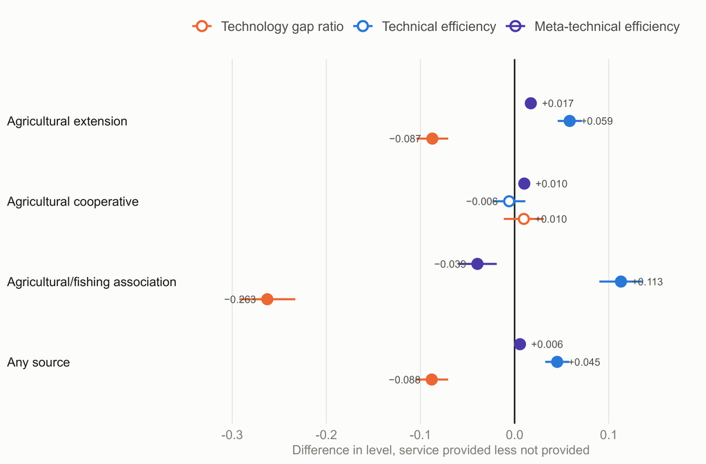

#### Figure 2. The association between community agricultural service provision and farm productivity from 2005-2017

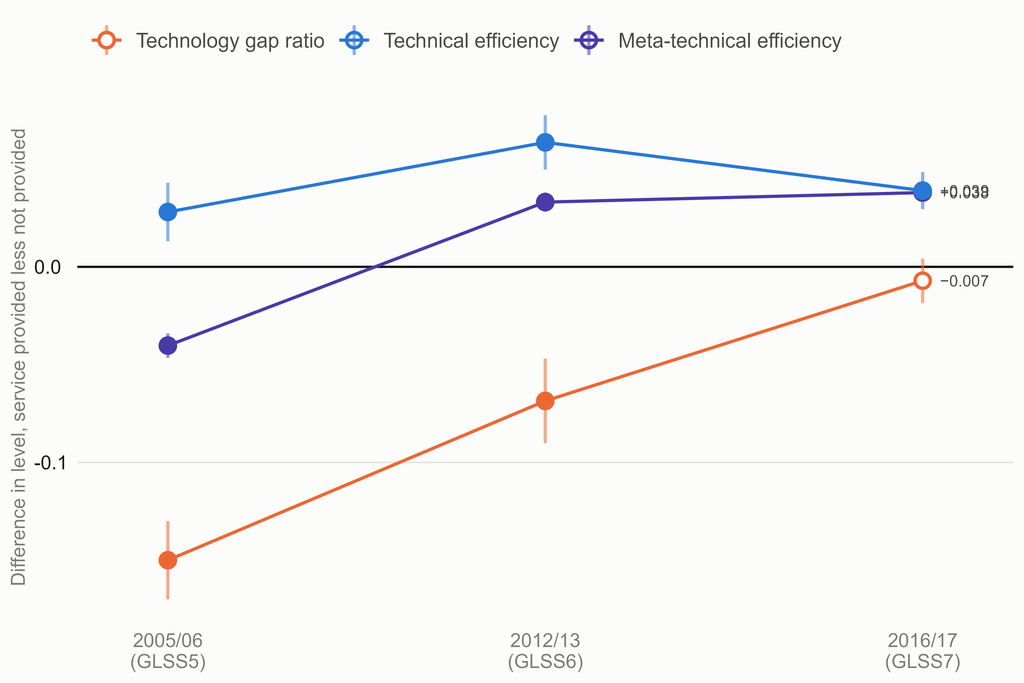

#### Figure 3. Community Agricultural Services and Farm Performance in Ghana

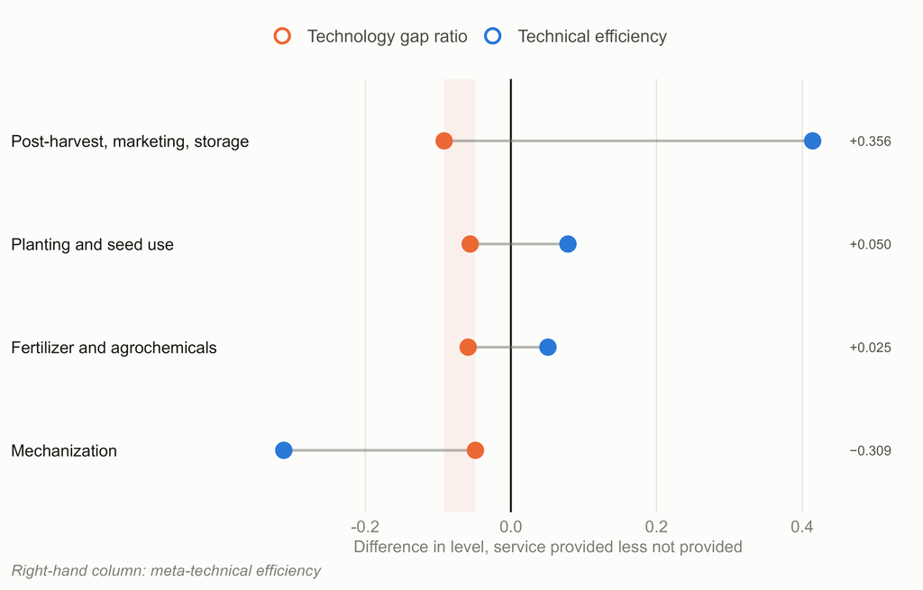

#### Figure 4. Agricultural Services Provision Association with Crop Production Technology Adoption and Technical Efficiency by Farmer Gender, Age, and Education in Ghana (2005-2017)

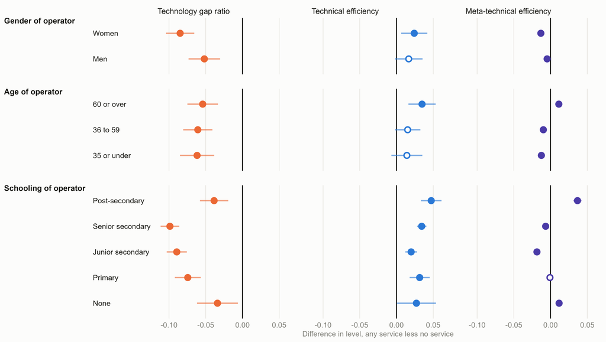

#### Figure 5. Agricultural Services Provision Association with Crop Production Technology Adoption and Technical Efficiency by Major Crops and Administrative Regions in Ghana (2005-2017)

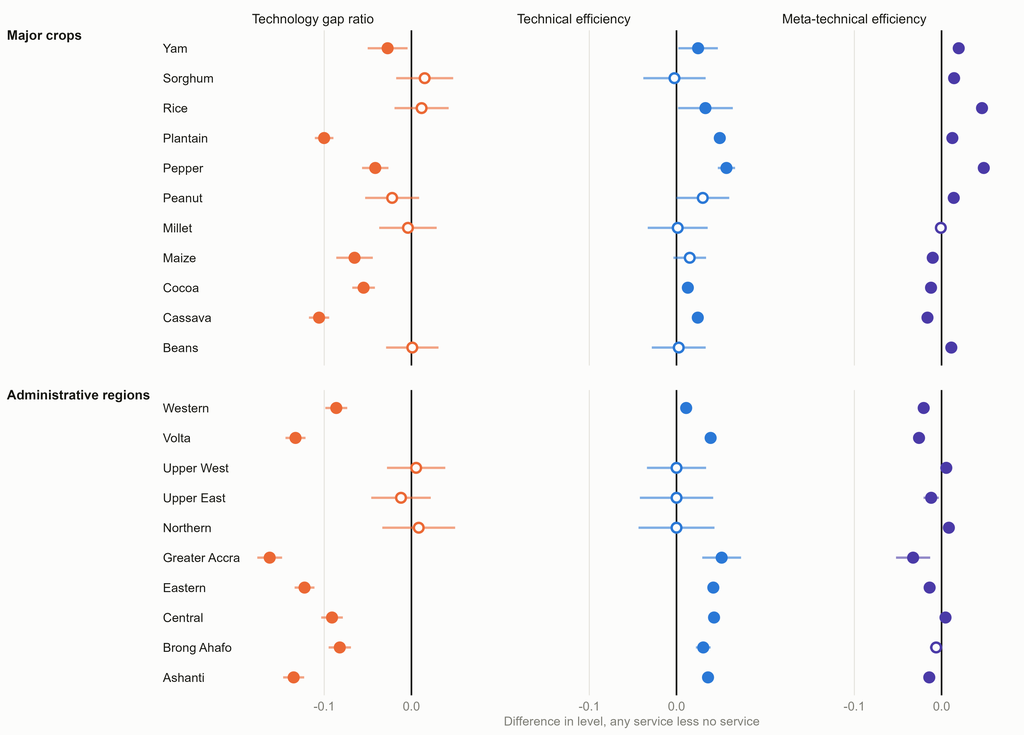

# Supplementary material

## Note S1. Construction and Harmonization of Community Agricultural Service Delivery Variables

### The community questionnaire and the merge

The consolidated farmer-level dataset harmonizes farm production outcomes across survey rounds but carries no community-level information on agricultural service provision. Those measures were built from the agriculture section of the GLSS community questionnaire and merged into the farmer-level data using survey and enumeration-area identifiers, so that every farm operator inherits the service environment of the enumeration area in which the household was sampled.

The community questionnaire is not administered to households. It is put to a panel of community opinion leaders, and the survey protocol requires that panel to reflect the occupational, ethnic, gender and religious composition of the locality. What the resulting variables record is therefore a key-informant report of what is available in a community. They are not administrative records of service delivery, and they are not household reports of services received. Three consequences follow. A community counted as served may contain farmers who never encountered the service. A community counted as unserved may contain farmers who obtained advice privately or from a neighbouring locality. And the reliability of an item depends on how visible the thing being reported is, so the presence of an extension officer is more dependably recorded than, for instance, the distance to an office few informants have travelled to.

Where a community contributes more than one record to the questionnaire, indicators are collapsed to a single observation per survey and enumeration area by taking the maximum across records. A service therefore counts as available if any informant record reports it. This rule is deliberately permissive: it treats disagreement among informants as evidence of presence rather than of absence, on the reasoning that an informant is more likely to be unaware of a service that exists than to invent one that does not. The direction of any resulting error is toward classifying communities as served, which works against finding a difference between the two groups rather than for it.

### Harmonization across rounds

Community agricultural service variables are harmonized using GLSS7 as the reference structure, since it is the most recent round and organizes the service questions most clearly. In GLSS7 the relevant items are cs5q5 to cs5q15. Between them they cover the presence of an agricultural extension office and the distance to it, whether an extension officer is stationed in the community, whether an officer visits farmers, the agency providing the service, the services extension agents provide, compliance with extension guidance, the presence of an agricultural or fishing association, the services that association provides, participation in an agricultural cooperative, and tractor availability.

GLSS6 is numbered identically to GLSS7 across this block and required no renaming. GLSS5 did. That round carries no compliance item, and because the item is absent rather than merely unasked, the questions following it sit one position earlier than their GLSS7 counterparts: the association, cooperative and tractor questions all shift. Mapping GLSS5 onto the GLSS7 structure is thus a renaming exercise rather than a recoding one. Table S2 reports that mapping in full, and Table S1 gives the source question and construction rule for every variable in the final set.

### Indicators of the source of provision

Four indicators of the institutional source of service delivery enter the analysis. A community is classified as having *any service source* if it has an agricultural or fishing association, an agricultural cooperative, or active extension; an *association* source if an agricultural or fishing association is present; a *cooperative* source if farmers participate in an agricultural cooperative; and an *active extension* source if an extension officer visits farmers in the community.

These are four separate binary treatments, each estimated against its own pair of group-specific frontiers, rather than four levels of a single categorical treatment. The distinction governs how the estimates may be combined. Because each contrast is fitted independently, the four sets of frontier parameters are not constrained to agree with one another, and the four estimated gaps are not components of a decomposition that sums to the aggregate.

### Indicators of service content

A second set of indicators captures the content of the services available: planting or seed-use support, mechanization, credit, irrigation, animal husbandry, fertilizer and other agrochemical inputs, post-harvest, marketing or storage support, communal labour, employment, and record-keeping. These enter the analysis as a disaggregation of an estimated gap rather than as treatments in their own right.

Three are built from the extension roster alone: planting or seed-use advice, irrigation, and animal husbandry. Three are built from the association roster alone: communal labour, employment, and record-keeping. The remainder are set to one if either roster reports the service, so credit, mechanization, agrochemical and fertilizer inputs, and post-harvest or marketing support record availability from either provider without distinguishing which.

The asymmetry carries a practical consequence a reader of Table 4 should hold on to. Comparing irrigation against credit in that table is comparing an extension-only measure against a pooled one, and the difference between the two is not a difference between service types alone. It also bears on the service-content disaggregation in Section 5: an indicator drawn from a single roster has a narrower base than one drawn from both, so the estimates behind the two are not equally precise even where their cell counts are similar. Nothing in the questionnaire permits a symmetric construction, since the two rosters do not offer the same options.

### The threshold for active extension

Active extension requires a threshold, because the underlying variable is not binary. The community questionnaire asks separately whether an extension office exists, whether an officer is stationed locally, and whether an officer visits farmers, and the harmonized variable combines the three into a set of states running from no extension presence of any kind through to office, stationed officer and visits together.

We classify a community as having active extension when an officer visits, which is the partition above which farmer-facing contact occurs. The reason lies in what the frontier estimates. A frontier characterises a technology a farmer can actually reach, and an extension office in a community no officer visits does not place a farmer on a different technology from one with no office at all. The alternative rule, counting any extension infrastructure as active, would pool communities where farmers have contact with an adviser and communities that have only a building.

The choice is not close-run, because the passive states are nearly empty. Table 3 reports the full distribution. Communities with a stationed officer and no visit account for 2% of farmers and communities with an office and no visit for 2%, against 32% where an officer visits and no other infrastructure is present. Moving the threshold down to any infrastructure would reclassify a small share of the sample while merging two exposures that differ in kind.

Two features of the underlying variable qualify how the threshold should be understood. Its lower states are not ordered by intensity: an office without an officer and an officer without an office are two kinds of passive presence rather than two rungs of a ladder, so the rule is a partition and not a dose threshold. And communities with an office or a stationed officer but no visits fall into the comparison group under this rule. Section 5 reports the estimates under a stricter definition that excludes those communities from the comparison group as well, so that the sensitivity of the results to this decision can be read rather than assumed.

### The comparison group for source-specific contrasts

The three source-specific treatments require one further rule, and it departs from the sibling studies in this repository. A community with no association but with a cooperative or active extension is set to missing rather than to zero, and so drops out of the association comparison entirely. The same applies to the cooperative and active-extension contrasts.

The reasoning is that such a community is treated under a different arm rather than untreated. Coding it zero would place served farms in the reference group, which does more than mislabel a category: it contaminates the frontier against which the treated group is measured, and it does so in the direction of understating any difference. The retained comparison group is therefore communities with no agricultural service source of any kind. What the resulting estimate identifies should be stated precisely. It is the difference between association-served communities and communities with no service source at all, and it is not the effect of an association relative to other service arrangements.

The rule is not costless. Of the 22,519 farm observations in the analysis sample, the association contrast retains 14,017, the cooperative contrast 11,994 and the active-extension contrast 20,056; the remainder are served under another arm and are excluded. Because all four contrasts draw on the same comparison group, their estimates are not statistically independent, and they should not be pooled or differenced as though drawn from separate samples. Section 5 reports a robustness arm in which the excluded communities are coded zero instead.

### Implausible values and item non-response

Implausible values are set to missing before the community-level collapse. Extension distances of 999 kilometres or more, and tractor counts of 99 or more, are treated as non-responses rather than as observations, on the reasoning that both are conventional sentinel codes rather than measurements. Both rules are applied to the community record rather than to the farm, so a single suppressed community removes the variable for every farm in its enumeration area.

Neither rule bites hard. Across the 1,960 community records behind GLSS5 to GLSS7, the distance rule suppresses 26 and the tractor rule 11, all of them in the two later rounds.

## Note S2. Drivers of technical inefficiency

#### Table S1. Final agricultural service delivery variables and GLSS7 source references

[output not shown]

Notes: GLSS7 is used as the reference naming convention for harmonization. GLSS6 follows the same structure as GLSS7 for the main agricultural service questions. GLSS5 uses a similar structure, but the association, cooperative, and tractor questions are shifted relative to GLSS7; these are renamed before appending. GLSS4 uses an older numeric structure, so its corresponding questions are mapped into the same service categories before the final harmonized dataset is created [GLSS4 is not part of this study's estimation sample, which spans GLSS5-GLSS7].

#### Table S2. Harmonization of agricultural service questions across GLSS rounds

| Harmonized concept | GLSS7 reference | GLSS6 source | GLSS5 source and recoding | glss4 |
| --- | --- | --- | --- | --- |
| Survey identifier | Surveyx = "GLSS7" | Surveyx = "GLSS6" | Surveyx = "GLSS5" | Surveyx = "GLSS4" |
| Enumeration area identifier | clusterno renamed to EaId, then EaId = EaId + 70000 | clust renamed to EaId | clust renamed to EaId (SHARES the GLSS6 identifier space) | eanum; EaId = 4000 + eanum |
| Agricultural extension office | cs5q5 | cs5q5 | cs5q5 | cs5q5 |
| Distance to extension office | cs5q6 | cs5q6 | cs5q6 | cs5q6 |
| Extension officer stationed in community | cs5q7 | cs5q7 | cs5q7 | Not asked; GLSS4 has no officer-stationed question. Generated as missing. |
| Extension officer visits farmers | cs5q8 | cs5q8 | cs5q8 | cs5q7 (GLSS4 is offset by one from here on, having no officer-stationed item) |
| Extension agency / provider | cs5q9, decoded to cs5q9x; stores "Mofa" | cs5q9, decoded to cs5q9x; stores "Mofa" | cs5q9, decoded to cs5q9x; stores "Ministry Of Food And Agriculture" IN FULL | cs5q8; numeric codes 1 MOFA, 2/3 NGO, 4 cooperative |
| Extension services provided | cs5q10a-cs5q10d, decoded to cs5q10ax-cs5q10dx | cs5q10a-cs5q10d | cs5q10a-cs5q10d | cs5q9a-cs5q9d; numeric codes mapped to the harmonized categories |
| planting or seed use | cs5q10a-d | cs5q10a-d | cs5q10a-d | cs5q9a-d, code 1 |
| agrochemicals or fertilizer | cs5q10a-d | cs5q10a-d | cs5q10a-d | cs5q9a-d, codes 2 and 7 |
| mechanization | cs5q10a-d | cs5q10a-d | cs5q10a-d | cs5q9a-d, code 3 |
| credit | cs5q10a-d | cs5q10a-d | cs5q10a-d | cs5q9a-d, code 4 |
| irrigation | cs5q10a-d | cs5q10a-d | cs5q10a-d | cs5q9a-d, code 5 |
| animal husbandry | cs5q10a-d | cs5q10a-d | cs5q10a-d | cs5q9a-d, code 6 |
| post-harvest, marketing or storage | cs5q10a-d | cs5q10a-d | cs5q10a-d | cs5q9a-d, code 8 |
| Compliance with extension advice | cs5q11 | cs5q11 | NOT ASKED. GLSS5's cs5q11 is the association question and is renamed to cs5q12; compliance has no GLSS5 source. | NOT ASKED. Generated as missing. |
| Agricultural/fishing association | cs5q12 | cs5q12 | original cs5q11 renamed to cs5q12 | cs5q10 (asks about a "cooperative" in the same structural slot) |
| Association services | cs5q13a-cs5q13c, decoded to cs5q13ax-cs5q13cx | cs5q13a-cs5q13c | original cs5q12a-cs5q12c renamed to cs5q13a-cs5q13c | cs5q11a-cs5q11c; numeric codes mapped to the harmonized categories |
| employment support | cs5q13a-c | cs5q13a-c | cs5q12a-c renamed to cs5q13a-c | cs5q11a-c, code 1 |
| credit support | cs5q13a-c | cs5q13a-c | cs5q12a-c renamed to cs5q13a-c | cs5q11a-c, code 2 |
| agricultural equipment | cs5q13a-c | cs5q13a-c | cs5q12a-c renamed to cs5q13a-c | cs5q11a-c, code 3 |
| agricultural inputs | cs5q13a-c | cs5q13a-c | cs5q12a-c renamed to cs5q13a-c | cs5q11a-c, code 4 |
| marketing | cs5q13a-c | cs5q13a-c | cs5q12a-c renamed to cs5q13a-c | cs5q11a-c, code 5 |
| records / book-keeping | cs5q13a-c | cs5q13a-c | cs5q12a-c renamed to cs5q13a-c | cs5q11a-c, code 6 |
| communal labour | cs5q13a-c | cs5q13a-c | cs5q12a-c renamed to cs5q13a-c | cs5q11a-c, code 7 |
| Agricultural cooperative participation | cs5q14 | cs5q14 | original cs5q13 renamed to cs5q14 | cs5q12 |
| Tractors used for agriculture | cs5q15 | cs5q15 | original cs5q14 renamed to cs5q15 | cs5q13; counts ALL tractors, not only agricultural ones |

Notes: GLSS7 is used as the reference naming convention for harmonization. GLSS6 follows the same structure as GLSS7 for the main agricultural service questions. GLSS5 uses a similar structure, but the association, cooperative, and tractor questions are shifted relative to GLSS7; these are renamed before appending. GLSS4 uses an older numeric structure, so its corresponding questions are mapped into the same service categories before the final harmonized dataset is created [GLSS4 is not part of this study's estimation sample, which spans GLSS5-GLSS7].

#### Table S3. Summary Statistics of Crop Producers in Ghana (2005-2017)

| Variable | Pooled (n=22,519) | Extension (n=11,752) | Community cooperative (n=3,690) | Farm association (n=5,713) |
| --- | --- | --- | --- | --- |
| Farmer a |  |  |  |  |
| Female farmer (dummy) | 0.25 (0.43) | 0.26 (0.44) | 0.24 (0.43) | 0.28 (0.45) † |
| Age (years) | 46.87 (15.26) | 47.35 (15.24) † | 46.86 (15.26) | 47.32 (14.89) |
| Education (years) | 4.17 (4.96) | 4.43 (5.11) | 4.52 (5.15) † | 5.22 (5.07) † |
| Cereal production a |  |  |  |  |
| All crops (maize kg/ha) | 1112.91 (1578.72) | 1191.86 (1729.80) † | 1162.62 (1728.27) † | 1135.14 (1652.84) † |
| Maize (Kg/ha) | 2279.06 (6343.69) | 2556.47 (7428.78) † | 2097.86 (6601.90) † | 2517.80 (7645.10) † |
| Rice (Kg/ha) | 1251.80 (2421.35) | 1290.10 (2557.22) | 941.78 (1463.64) † | 1329.45 (2362.02) |
| Millet (Kg/ha) | 952.19 (1679.78) | 1063.37 (1991.63) † | 992.30 (1734.67) † | 1325.74 (2281.52) † |
| Sorghum (Kg/ha) | 881.35 (1354.99) | 947.71 (1550.81) | 795.83 (1156.13) † | 1022.93 (1554.19) † |
| Beans (Kg/ha) | 946.28 (2008.86) | 1019.62 (2365.53) † | 705.30 (1093.35) † | 875.36 (2065.68) |
| Peanut (Kg/ha) | 1160.02 (2298.37) | 1123.48 (2223.65) | 1002.91 (1609.98) † | 1223.88 (2338.00) |
| Cassava (Kg/ha) | 1116.24 (2351.95) | 1261.37 (2714.28) † | 1277.47 (3025.10) † | 950.86 (2243.58) |
| Yam (Kg/ha) | 1370.95 (2584.14) | 1203.92 (2323.64) † | 1021.11 (1899.17) † | 1150.13 (2117.13) † |
| Cocoyam (Kg/ha) | 383.92 (968.73) | 377.86 (861.97) | 899.23 (1843.97) † | 349.69 (1037.80) |
| Plantain (Kg/ha) | 810.43 (1745.83) | 913.75 (1926.95) † | 973.79 (2176.06) † | 678.48 (1556.31) |
| Pepper (Kg/ha) | 515.71 (1300.16) | 516.30 (1278.46) | 371.01 (883.00) | 366.57 (762.39) |
| Okra (kg/ha) | 333.60 (646.33) | 378.70 (761.11) | 517.31 (796.56) | 413.85 (872.10) |
| Tomatoe (kg/ha) | 418.39 (1106.52) | 451.32 (1126.32) | 628.43 (1577.83) | 466.33 (1144.73) |
| Cocoa (Kg/ha) | 647.74 (1526.86) | 696.70 (1750.58) † | 809.42 (2022.68) † | 648.84 (1622.73) † |
| Palm (Kg/ha) | 1322.17 (3387.38) | 1585.14 (4023.52) | 956.20 (2430.68) | 1508.92 (4471.86) |
| Land (ha) | 1.86 (2.56) | 1.83 (2.62) | 1.95 (2.75) † | 1.82 (2.51) |
| Land owned (dummy) | 0.64 (0.48) | 0.64 (0.48) | 0.66 (0.47) | 0.64 (0.48) † |
| Crop diversification (index) | 0.49 (0.26) | 0.49 (0.26) † | 0.47 (0.26) † | 0.47 (0.26) |
| Seed (GHC/ha) | 109.94 (608.03) | 120.72 (725.15) | 149.57 (1067.98) † | 71.40 (319.89) † |
| Household labor (AE) | 7.21 (6.66) | 7.20 (6.48) † | 6.70 (6.21) | 6.62 (6.26) † |
| Hired labor (man-days/ha) | 19.61 (122.65) | 20.41 (146.77) | 20.07 (101.04) | 20.81 (75.84) |
| Fertilizer (Kg/ha) | 204.52 (6715.58) | 163.32 (784.26) | 212.53 (755.15) † | 144.00 (465.62) |
| Pesticide (Liter/ha) | 14.94 (276.61) | 13.03 (40.49) † | 16.94 (50.97) † | 21.99 (545.25) |
| Mechanization (dummy) | 0.05 (0.21) | 0.06 (0.23) † | 0.06 (0.24) † | 0.03 (0.16) † |
| Irrigation (dummy) | 0.01 (0.12) | 0.02 (0.12) | 0.02 (0.14) † | 0.02 (0.12) |
| Credit (dummy) | 0.15 (0.36) | 0.15 (0.36) † | 0.15 (0.36) | 0.17 (0.38) |
| Household b |  |  |  |  |
| Size (AE) | 5.49 (3.22) | 5.40 (3.13) | 5.55 (3.21) | 5.21 (3.07) † |
| Dependency (ratio) | 1.43 (1.69) | 1.44 (1.69) | 1.45 (1.73) | 1.40 (1.65) |

Notes: Standard deviations in parentheses; clustered standard errors in brackets. Significance levels: * p<0.10, ** p<0.05, *** p<0.01.  
a Trend is the average semi-elasticity from a regression of the variable on a linear year trend interacted with service status, expressed as percent per year. Standard errors are clustered by survey-ecozone-enumeration area-household.  
† marks a group difference significant at the 10 percent level (Wald test on the service-status term for means, on the trend-by-service interaction for trends).  
b The pooled column is the full analysis sample. The three source columns are the farmers served by that source; because a farmer served by another source is excluded from a source's comparison, the source columns do not sum to the pooled column.

#### Table S4. Trends in the Characteristics of Crop Producers in Ghana (2005-2017)

| Variable | Pooled (n=22,519) | Extension (n=11,752) | Community cooperative (n=3,690) | Farm association (n=5,713) |
| --- | --- | --- | --- | --- |
| Farmer a |  |  |  |  |
| Female farmer (dummy) | -0.71** [0.31] | -0.05 [0.42] † | -0.18 [0.89] | -1.06* [0.58] |
| Age (years) | 0.39*** [0.06] | 0.27*** [0.09] | 0.34* [0.19] | 0.35*** [0.12] |
| Education (years) | 1.84*** [0.24] | 3.05*** [0.32] † | 1.23* [0.64] | 1.66*** [0.36] |
| Cereal production a |  |  |  |  |
| All crops (maize kg/ha) | 8.76*** [0.31] | 10.69*** [0.48] † | 14.10*** [1.75] † | 11.48*** [0.73] † |
| Maize (Kg/ha) | 5.86*** [0.86] | 11.31*** [1.58] † | 32.39 [38.28] † | 14.31*** [3.15] † |
| Rice (Kg/ha) | -1.40 [1.31] | -2.64 [1.83] | 6.50** [2.79] † | -5.65* [3.24] |
| Millet (Kg/ha) | -1.03 [0.77] | -4.38*** [1.25] † | 5.08*** [1.32] † | -4.49** [1.97] † |
| Sorghum (Kg/ha) | -0.12 [0.70] | 0.42 [1.00] | 4.26** [1.83] † | -3.47** [1.75] † |
| Beans (Kg/ha) | 1.01 [1.03] | -1.97 [1.65] † | 7.12*** [2.09] † | 1.54 [2.84] |
| Peanut (Kg/ha) | 4.37*** [0.84] | 3.75*** [1.17] | 6.95*** [2.41] | 5.06** [2.04] |
| Cassava (Kg/ha) | 23.96*** [3.44] | 30.36*** [7.08] † | -35.74 [31.50] † | 22.95*** [5.05] |
| Yam (Kg/ha) | 36.36 [34.39] | 48.23* [27.98] † | -0.44 [4.03] | 304.07 [2327.67] |
| Cocoyam (Kg/ha) | 72.14 [135.97] | 13.11 [53.14] | 0.64 [3.70] † | 10.94 [71.28] |
| Plantain (Kg/ha) | 54.41* [29.12] | 68.35 [47.49] | -31.47* [18.62] † | 30.58*** [9.26] † |
| Pepper (Kg/ha) | -54.20 [62.75] | -42.33 [50.63] | 0.24 [4.76] | 140.84 [596.31] |
| Okra (kg/ha) | 9.69*** [2.38] | 11.98*** [4.13] † | 3.30 [3.89] | 14.20* [7.26] |
| Tomatoe (kg/ha) | 10.67*** [2.97] | 8.43** [3.58] | 121.60 [1130.05] | 10.71** [4.23] |
| Cocoa (Kg/ha) | 8.78*** [1.78] | 12.22*** [2.94] † | 30.82 [145.28] † | 16.81*** [5.52] † |
| Palm (Kg/ha) | 2.72 [2.22] | 4.11 [2.87] | 57.93 [405.35] † | 5.05 [4.68] |
| Land (ha) | 0.11 [0.25] | -0.04 [0.35] | -2.59*** [0.80] † | -0.09 [0.45] |
| Land owned (dummy) | -0.39*** [0.13] | -0.71*** [0.17] † | -0.44 [0.37] | -1.04*** [0.25] † |
| Crop diversification (index) | -1.94*** [0.10] | -2.39*** [0.13] † | -1.38*** [0.31] † | -2.63*** [0.21] † |
| Seed (GHC/ha) | -100.53 [2421.42] | 41.07 [42.70] † | 3.16* [1.68] † | 17.22*** [3.77] † |
| Household labor (AE) | 1.96*** [0.17] | 1.12*** [0.23] † | 0.80 [0.56] † | -0.01 [0.35] † |
| Hired labor (man-days/ha) | 0.44 [1.54] | 1.49 [2.54] | -2.10 [3.30] | 3.34*** [1.22] † |
| Fertilizer (Kg/ha) | 7.35 [10.13] | 17.27*** [4.19] | 12.33*** [4.09] | 21.35*** [4.29] |
| Pesticide (Liter/ha) | 20.54 [64.59] | 43.88*** [15.74] † | 15.78*** [3.92] | -128.55 [1069.58] |
| Mechanization (dummy) | -0.36 [1.19] | -3.56*** [1.15] † | -7.34*** [2.30] † | 3.17 [2.35] † |
| Irrigation (dummy) | 8.96*** [1.63] | 13.09*** [1.92] † | 2.03 [2.49] † | 6.33** [2.95] |
| Credit (dummy) | -7.53*** [0.48] | -5.35*** [0.64] † | -8.40*** [1.31] | -6.45*** [0.86] |
| Household b |  |  |  |  |
| Size (AE) | 0.11 [0.14] | -0.18 [0.17] † | -0.25 [0.37] | 0.11 [0.24] |
| Dependency (ratio) | -0.29 [0.24] | -0.34 [0.32] | 0.12 [0.72] | -0.22 [0.47] |

Notes: Standard deviations in parentheses; clustered standard errors in brackets. Significance levels: * p<0.10, ** p<0.05, *** p<0.01.  
a Trend is the average semi-elasticity from a regression of the variable on a linear year trend interacted with service status, expressed as percent per year. Standard errors are clustered by survey-ecozone-enumeration area-household.  
† marks a group difference significant at the 10 percent level (Wald test on the service-status term for means, on the trend-by-service interaction for trends).  
b Cells are percent change per year. See Table S3 for the levels the trends are computed on.

#### Table S5. Covariate balancing

| Covariate | Statistic | Unmatched | euclidean | scaled_euclidean | mahalanobis | robust_mahalanobis | logit | probit | cloglog | cauchit |
| --- | --- | --- | --- | --- | --- | --- | --- | --- | --- | --- |
| AgeYr | KS statistic | 0.0354 | 0.0169 | 0.0220 | 0.0200 | 0.0227 | 0.0296 | 0.0371 | 0.0245 | 0.0667 |
| AgeYr | Std. mean difference | 0.0840 | 0.0185 | 0.0304 | 0.0149 | 0.0167 | 0.0656 | 0.0820 | 0.0536 | 0.1544 |
| AgeYr | Variance ratio | 1.0107 | 1.0338 | 1.0411 | 1.0524 | 1.0430 | 1.0082 | 1.0252 | 1.0094 | 1.0131 |
| Area_Beans | KS statistic | 0.0097 | 0.0060 | 0.0057 | 0.0062 | 0.0035 | 0.0046 | 0.0104 | 0.0073 | 0.0195 |
| Area_Beans | Std. mean difference | 0.0081 | 0.0013 | 0.0031 | 0.0022 | 0.0079 | 0.0093 | 0.0362 | 0.0162 | 0.0555 |
| Area_Beans | Variance ratio | 1.0136 | 1.0337 | 1.0288 | 1.0358 | 1.0436 | 1.0602 | 1.2206 | 1.0829 | 1.2345 |
| Area_Cassava | KS statistic | 0.0308 | 0.0252 | 0.0255 | 0.0220 | 0.0153 | 0.0237 | 0.0348 | 0.0181 | 0.0381 |
| Area_Cassava | Std. mean difference | 0.0406 | 0.0140 | 0.0078 | 0.0015 | 0.0052 | 0.0152 | 0.0502 | 0.0049 | 0.0664 |
| Area_Cassava | Variance ratio | 1.0337 | 1.0388 | 1.0606 | 1.0863 | 1.0431 | 1.0244 | 1.0472 | 1.0385 | 1.0773 |
| Area_Cocoa | KS statistic | 0.0215 | 0.0133 | 0.0212 | 0.0228 | 0.0173 | 0.0256 | 0.0551 | 0.0254 | 0.0247 |
| Area_Cocoa | Std. mean difference | 0.0302 | 0.0048 | 0.0245 | 0.0298 | 0.0436 | 0.0410 | 0.1516 | 0.0422 | 0.0648 |
| Area_Cocoa | Variance ratio | 1.0543 | 1.0146 | 1.0234 | 1.0382 | 1.0896 | 1.0577 | 1.5578 | 1.0616 | 1.1691 |
| Area_Cocoyam | KS statistic | 0.0248 | 0.0157 | 0.0130 | 0.0106 | 0.0089 | 0.0121 | 0.0157 | 0.0122 | 0.0219 |
| Area_Cocoyam | Std. mean difference | 0.0640 | 0.0451 | 0.0024 | 0.0034 | 0.0376 | 0.0343 | 0.0508 | 0.0362 | 0.1091 |
| Area_Cocoyam | Variance ratio | 2.1138 | 1.8658 | 1.1091 | 1.0947 | 1.7014 | 1.6229 | 1.8369 | 1.6244 | 2.8814 |
| Area_Maize | KS statistic | 0.0286 | 0.0207 | 0.0227 | 0.0273 | 0.0091 | 0.0211 | 0.0287 | 0.0253 | 0.0505 |
| Area_Maize | Std. mean difference | 0.0456 | 0.0141 | 0.0011 | 0.0116 | 0.0015 | 0.0306 | 0.0330 | 0.0419 | 0.0956 |
| Area_Maize | Variance ratio | 1.0154 | 1.0462 | 1.0379 | 1.0262 | 1.0032 | 1.0360 | 1.0058 | 1.0369 | 1.1047 |
| Area_Millet | KS statistic | 0.0060 | 0.0036 | 0.0072 | 0.0060 | 0.0039 | 0.0040 | 0.0056 | 0.0074 | 0.0066 |
| Area_Millet | Std. mean difference | 0.0207 | 0.0039 | 0.0093 | 0.0023 | 0.0004 | 0.0003 | 0.0023 | 0.0157 | 0.0299 |
| Area_Millet | Variance ratio | 1.1367 | 1.0453 | 1.0321 | 1.0257 | 1.0042 | 1.0316 | 1.0544 | 1.0468 | 1.2573 |
| Area_Okra | KS statistic | 0.0141 | 0.0204 | 0.0175 | 0.0180 | 0.0102 | 0.0242 | 0.0256 | 0.0225 | 0.0291 |
| Area_Okra | Std. mean difference | 0.0384 | 0.0380 | 0.0024 | 0.0007 | 0.0036 | 0.0516 | 0.0667 | 0.0413 | 0.0893 |
| Area_Okra | Variance ratio | 1.3816 | 1.3384 | 1.6268 | 1.6472 | 1.5759 | 1.5589 | 1.7011 | 1.3334 | 2.2529 |
| Area_Palm | KS statistic | 0.0193 | 0.0111 | 0.0088 | 0.0084 | 0.0038 | 0.0212 | 0.0280 | 0.0185 | 0.0327 |
| Area_Palm | Std. mean difference | 0.0574 | 0.0090 | 0.0109 | 0.0068 | 0.0050 | 0.0721 | 0.1058 | 0.0577 | 0.1254 |
| Area_Palm | Variance ratio | 1.4694 | 1.0420 | 1.1466 | 1.0850 | 1.0199 | 1.5546 | 1.7935 | 1.4369 | 1.9635 |
| Area_Peanut | KS statistic | 0.0393 | 0.0120 | 0.0084 | 0.0088 | 0.0106 | 0.0119 | 0.0114 | 0.0102 | 0.0220 |
| Area_Peanut | Std. mean difference | 0.1285 | 0.0171 | 0.0182 | 0.0211 | 0.0342 | 0.0243 | 0.0310 | 0.0051 | 0.0828 |
| Area_Peanut | Variance ratio | 1.4589 | 1.1651 | 1.1221 | 1.1372 | 1.1422 | 1.2014 | 1.2025 | 1.0977 | 1.4281 |

[output cut: 131 more lines]

Balance is best where the standardised mean difference is near zero, the variance ratio near one and the KS statistic near zero.  
The unadjusted column is the sample before matching and is identical across specifications.

#### Table S6. Covariate balance summary

| Scaling matrix | Mean standardized differences [A] | Mean variance ratio [B] | Kolmogorov- Smirnov (KS) Statistics [C] | Selection criteria [((A-0)²+(B-1)²+(C-0)²)/3] |
| --- | --- | --- | --- | --- |
| Scaled Euclidean | 0.0127 | 1.1167 | 0.0125 | 0.0108 |
| Mahalanobis | 0.0127 | 1.1162 | 0.0133 | 0.0108 |
| Euclidean | 0.0128 | 1.1303 | 0.0125 | 0.0175 |
| Robust Mahalanobis | 0.0145 | 1.1423 | 0.0125 | 0.0181 |
| Complementary Log-Log [PS] | 0.0249 | 1.2010 | 0.0169 | 0.0380 |
| Probit [PS] | 0.0370 | 1.2377 | 0.0231 | 0.0489 |
| Logit [PS] | 0.0273 | 1.2891 | 0.0170 | 0.0933 |
| Cauchit [PS] | 0.0391 | 1.3661 | 0.0225 | 0.1161 |

Rows are ordered by the selection criterion; the chosen specification is Scaled Euclidean, shown in bold. [PS] marks a propensity-score link rather than a scaling matrix.

#### Table S7. Meta Stochastic Frontier Analysis Results for Ghanaian Crop Producers for the periods 2005/06, 2012/13 and 2016/17

|  | Naïve national frontier | Group frontier No services | Group frontier Some services | Meta-frontier Matched | Meta-frontier Unmatched |
| --- | --- | --- | --- | --- | --- |
| Production function |  |  |  |  |  |
| Land [lnI1] | 0.797*** (0.001) | 0.804*** (0.002) | 0.805*** (0.001) | 0.803*** (0.001) | 0.798*** (0.001) |
| Planting material [lnI2] | 0.058*** (0.000) | 0.067*** (0.000) | 0.053*** (0.000) | 0.061*** (0.000) | 0.060*** (0.000) |
| Family labor [lnI3] | 0.168*** (0.002) | 0.182*** (0.002) | 0.167*** (0.002) | 0.180*** (0.002) | 0.173*** (0.002) |
| Hired labor [lnI4] | 0.034*** (0.000) | 0.031*** (0.000) | 0.036*** (0.000) | 0.033*** (0.000) | 0.033*** (0.000) |
| Fertilizer [lnI5] | 0.024*** (0.000) | 0.020*** (0.000) | 0.026*** (0.000) | 0.022*** (0.000) | 0.023*** (0.000) |
| Pesticide [lnI6] | 0.031*** (0.000) | 0.030*** (0.000) | 0.031*** (0.000) | 0.029*** (0.000) | 0.029*** (0.000) |
| 1/2 * lnI1 * lnI1 | -0.016*** (0.001) | -0.020*** (0.001) | -0.009*** (0.001) | -0.013*** (0.001) | -0.014*** (0.001) |
| lnI1*lnI2 | -0.000 (0.000) | 0.000 (0.000) | 0.000 (0.000) | 0.000* (0.000) | -0.000*** (0.000) |
| lnI1*lnI3 | -0.047*** (0.000) | -0.053*** (0.001) | -0.047*** (0.000) | -0.048*** (0.000) | -0.046*** (0.000) |
| lnI1*lnI4 | -0.000 (0.000) | 0.000 (0.000) | 0.000* (0.000) | 0.000*** (0.000) | 0.000** (0.000) |
| lnI1*lnI5 | 0.000 (0.000) | -0.000 (0.000) | 0.000 (0.000) | 0.000*** (0.000) | 0.000** (0.000) |
| lnI1*lnI6 | 0.000 (0.000) | -0.000 (0.000) | 0.000 (0.000) | 0.000*** (0.000) | 0.000*** (0.000) |
| 1/2 * lnI2 * lnI2 | 0.005*** (0.000) | 0.006*** (0.000) | 0.005*** (0.000) | 0.005*** (0.000) | 0.005*** (0.000) |
| lnI2*lnI3 | -0.000 (0.000) | -0.000 (0.000) | 0.000 (0.000) | -0.000 (0.000) | -0.000*** (0.000) |
| lnI2*lnI4 | -0.000 (0.000) | 0.000 (0.000) | -0.000 (0.000) | -0.000 (0.000) | -0.000 (0.000) |
| lnI2*lnI5 | -0.000 (0.000) | -0.000 (0.000) | -0.000 (0.000) | -0.000*** (0.000) | -0.000 (0.000) |
| lnI2*lnI6 | -0.000 (0.000) | -0.000 (0.000) | -0.000 (0.000) | -0.000*** (0.000) | -0.000*** (0.000) |
| 1/2 * lnI3 * lnI3 | 0.006*** (0.001) | -0.001 (0.001) | 0.006*** (0.001) | 0.001 (0.001) | 0.002** (0.001) |
| lnI3*lnI4 | 0.000 (0.000) | -0.000 (0.000) | -0.000 (0.000) | 0.000*** (0.000) | 0.000* (0.000) |
| lnI3*lnI5 | 0.000 (0.000) | 0.000 (0.000) | 0.000 (0.000) | 0.000*** (0.000) | 0.000*** (0.000) |
| lnI3*lnI6 | -0.000 (0.000) | 0.000 (0.000) | 0.000 (0.000) | 0.000*** (0.000) | 0.000*** (0.000) |
| 1/2 * lnI4 * lnI4 | 0.003*** (0.000) | 0.003*** (0.000) | 0.003*** (0.000) | 0.003*** (0.000) | 0.003*** (0.000) |
| lnI4*lnI5 | 0.000 (0.000) | 0.000 (0.000) | -0.000 (0.000) | 0.000*** (0.000) | 0.000 (0.000) |
| lnI4*lnI6 | 0.000 (0.000) | -0.000 (0.000) | -0.000 (0.000) | 0.000 (0.000) | -0.000*** (0.000) |
| 1/2 * lnI5 * lnI5 | 0.002*** (0.000) | 0.001*** (0.000) | 0.002*** (0.000) | 0.002*** (0.000) | 0.002*** (0.000) |
| lnI5*lnI6 | -0.000 (0.000) | 0.000*** (0.000) | -0.000 (0.000) | 0.000*** (0.000) | 0.000*** (0.000) |
| 1/2 * lnI6 * lnI6 | 0.003*** (0.000) | 0.002*** (0.000) | 0.003*** (0.000) | 0.002*** (0.000) | 0.002*** (0.000) |
| Proportion of area under listed crop |  |  |  |  |  |
| Beans | -0.055*** (0.006) | 0.040*** (0.006) | -0.074*** (0.008) | -0.063*** (0.008) | -0.048*** (0.008) |
| Cassava | -0.085*** (0.006) | 0.019*** (0.006) | -0.109*** (0.008) | -0.088*** (0.008) | -0.075*** (0.008) |
| Cocoa | 0.365*** (0.008) | 0.447*** (0.012) | 0.370*** (0.009) | 0.368*** (0.010) | 0.386*** (0.009) |
| Maize | 0.043*** (0.000) | 0.057*** (0.000) | 0.038*** (0.000) | 0.055*** (0.000) | 0.051*** (0.001) |
| Millet | -0.035*** (0.006) | 0.079*** (0.006) | -0.063*** (0.008) | -0.033*** (0.008) | -0.025*** (0.007) |
| Other | -0.086*** (0.006) | 0.013** (0.006) | -0.108*** (0.008) | -0.093*** (0.008) | -0.078*** (0.008) |
| Peanut | -0.014** (0.006) | 0.104*** (0.006) | -0.042*** (0.008) | -0.004 (0.008) | 0.002 (0.007) |
| Pepper | -0.086*** (0.007) | -0.046*** (0.006) | -0.106*** (0.009) | -0.092*** (0.009) | -0.077*** (0.008) |
| Plantain | -0.078*** (0.006) | 0.014** (0.006) | -0.097*** (0.008) | -0.087*** (0.008) | -0.069*** (0.008) |
| Rice | -0.051*** (0.006) | 0.043*** (0.006) | -0.074*** (0.008) | -0.057*** (0.008) | -0.043*** (0.008) |
| Sorghum | -0.023*** (0.006) | 0.049*** (0.006) | -0.037*** (0.008) | -0.029*** (0.008) | -0.014* (0.008) |
| Yam | -0.072*** (0.006) | 0.032*** (0.006) | -0.098*** (0.008) | -0.074*** (0.008) | -0.061*** (0.008) |
| Ecological zone [base = Coastal Savanna] |  |  |  |  |  |
| Forest | 0.471*** (0.005) | 0.486*** (0.007) | 0.450*** (0.006) | 0.476*** (0.007) | 0.450*** (0.008) |
| Guinea Savanah | -0.813*** (0.005) | -0.917*** (0.023) | -0.760*** (0.007) | -0.903*** (0.021) | -0.901*** (0.022) |
| Sudan Savanah | -0.876*** (0.005) | -0.971*** (0.018) | -0.808*** (0.007) | -0.951*** (0.014) | -0.940*** (0.013) |
| Transitional | -0.046*** (0.005) | -0.088*** (0.007) | -0.042*** (0.006) | -0.087*** (0.007) | -0.086*** (0.007) |
| Period [base = 2005/06] |  |  |  |  |  |
| 2012/13 | 0.151*** (0.003) | 0.101*** (0.006) | 0.177*** (0.004) | 0.099*** (0.007) | 0.114*** (0.011) |
| 2016/17 | 0.295*** (0.003) | 0.193*** (0.009) | 0.362*** (0.004) | 0.259*** (0.013) | 0.246*** (0.014) |
| Intercept | 6.714*** (0.008) | 6.729*** (0.015) | 6.666*** (0.011) | 6.895*** (0.012) | 6.854*** (0.021) |
| Production risk function |  |  |  |  |  |
| Intercept | -0.305*** (0.001) | -0.375*** (0.006) | -0.270*** (0.002) | -7.866*** (0.237) | -6.054*** (0.364) |

Standard errors in parentheses. Significance levels: * p<0.10, ** p<0.05, *** p<0.01.  
Meta stochastic frontier analysis of a translog production function in six inputs, jointly estimated on Ghana Living Standards Survey waves 5-7.  
The naive national frontier pools both groups; the group frontiers are estimated separately for communities with and without agricultural services.

#### Table S8. Determinants Of Crop Production Technical Inefficiency and Agricultural Service Driven Technology Gaps in Ghana (2005-2017)

|  | Naïve national frontier | Group frontier No services | Group frontier Some services | Meta-frontier Matched | Meta-frontier Unmatched |
| --- | --- | --- | --- | --- | --- |
| Female farmer (dummy) | 0.280*** (0.003) | 0.257*** (0.010) | 0.294*** (0.003) | 0.448*** (0.015) | 0.412*** (0.020) |
| Age (years) | 0.042*** (0.004) | -0.009 (0.007) | 0.100*** (0.004) | 0.074*** (0.010) | 0.012 (0.012) |
| Education (years) | 0.009*** (0.000) | 0.010*** (0.000) | 0.008*** (0.000) | 0.013*** (0.000) | 0.015*** (0.001) |
| Land owned (dummy) | 0.031*** (0.003) | -0.042*** (0.007) | 0.068*** (0.004) | -0.076*** (0.007) | -0.115*** (0.011) |
| Crop diversification (index) | 0.479*** (0.005) | 0.529*** (0.006) | 0.467*** (0.007) | -0.627*** (0.026) | -0.913*** (0.058) |
| Mechanization (dummy) | -0.095*** (0.016) | 0.291 (0.253) | -0.246*** (0.023) | -0.002 (0.031) | -0.470*** (0.084) |
| Credit (dummy) | 0.062*** (0.003) | -0.005 (0.006) | 0.099*** (0.003) | -0.105*** (0.020) | -0.030*** (0.009) |
| Ecological zone [base = Coastal Savanna] |  |  |  |  |  |
| Forest | 0.608*** (0.007) | 0.649*** (0.012) | 0.538*** (0.010) | 0.066 (0.073) | -0.102 (0.100) |
| Guinea Savanah | -41.354*** (4.813) | -224.649 (158.008) | -43.138*** (1.869) | -1.254*** (0.194) | -2.274*** (0.497) |
| Sudan Savanah | -675.230*** (234.707) | -19.804*** (4.664) | -44.227*** (6.114) | -0.833*** (0.110) | -0.846*** (0.225) |
| Transitional | 0.077*** (0.008) | 0.040*** (0.010) | 0.044*** (0.011) | -0.269*** (0.068) | -0.453*** (0.099) |
| Period [base = 2005/06] |  |  |  |  |  |
| 2012/13 | -0.358*** (0.005) | -0.429*** (0.012) | -0.323*** (0.006) | -0.852*** (0.082) | -0.943*** (0.109) |
| 2016/17 | -1.605*** (0.010) | -1.473*** (0.017) | -1.663*** (0.013) | -0.506*** (0.168) | -1.355*** (0.115) |
| Intercept | 0.209*** (0.018) | 0.555*** (0.036) | -0.071*** (0.020) | -3.197*** (0.098) | -2.883*** (0.138) |

Standard errors in parentheses. Significance levels: * p<0.10, ** p<0.05, *** p<0.01.  
Determinants of technical inefficiency. A POSITIVE coefficient raises inefficiency, and therefore lowers technical efficiency.  
Age and education enter in logs, as specified in 004_MSF_ag_services_study.R.

#### Figure S1. Covariate balance before and after matching

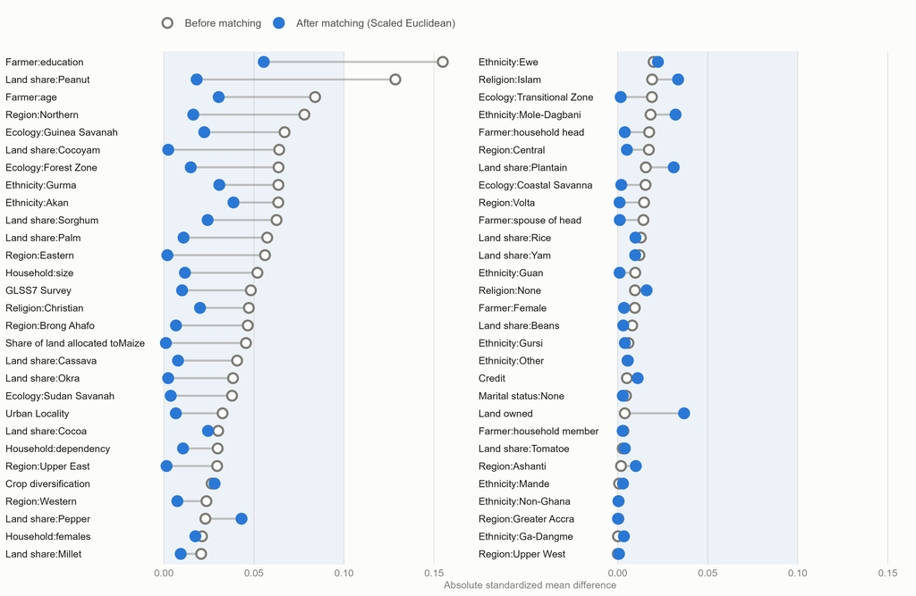

#### Figure S2. Different Model Specifications Generally Show Increasing Impact of Farmer Agricultural Service Provision on Crop Production Output for Ghanaian Farmers (2005-2017)

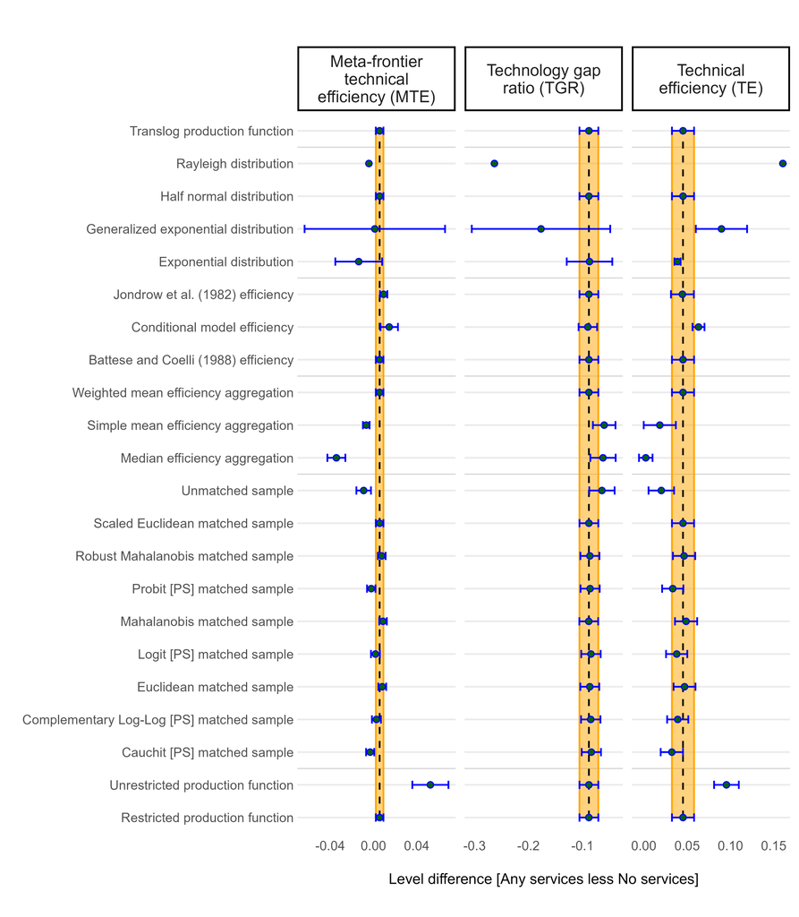